# Cox_interactions

Laura Blanco

Uploading libraries

```r
library(survival)
library(survminer)
library(ranger)
library(ggplot2)
library(dplyr)
library(ggfortify)
library(ggpubr)
library(ggsci)
library(readxl)
library(showtext)
library(lubridate)
```

Uploading & preparing data

```r
setwd("C:\\Users\\lblan\\OneDrive\\Escritorio\\CEAB\\2022\\First_chapter")
data_analysis <- read_excel("C:/Users/lblan/OneDrive/Escritorio/CEAB/2022/First_chapter/data_analysis_cens.xlsx",
                            col_types = c("numeric", "date", "date",
                                          "numeric", "numeric", "numeric", "numeric"))

jardin_clima <- read_excel("C:/Users/lblan/OneDrive/Escritorio/CEAB/2022/Jardin_clima_total.xlsx",
                           col_types = c("date", "numeric", "numeric"))

palafolls_clima <- read_excel("C:/Users/lblan/OneDrive/Escritorio/CEAB/2022/Palafolls_clima_total.xlsx",
                              col_types = c("date", "numeric", "numeric"))
```

Preparing weather data - Urban area (Palafolls)

```r
temperaturemeanpal<- palafolls_clima%>% #v#calculating means of temperature and rhper day (HOBO makes 3 measures per day)
  group_by(DATE)%>%
  summarise(meantemperature=mean(TEMPERATURE),meanrh = mean(RH) )

temperatureminpal<- palafolls_clima%>% #v#calculating mins of temperature and rhper day (HOBO makes 3 measures per day)
  group_by(DATE)%>%
  summarise(mintemperature=min(TEMPERATURE),minrh = min(RH) )

temperaturemaxpal<- palafolls_clima%>% #v#calculating max of temperature and rhper day (HOBO makes 3 measures per day)
  group_by(DATE)%>%
  summarise(maxtemperature=max(TEMPERATURE),maxrh = max(RH) )
palafolls_clima<- merge(temperaturemaxpal, temperaturemeanpal, by = "DATE")
palafolls_clima_total<- merge(palafolls_clima, temperatureminpal, by = "DATE")
remove(palafolls_clima)
remove(temperaturemaxpal)
remove(temperatureminpal)
remove(temperaturemeanpal)
```

Preparing weather data - Semi Urban area (Jardín Botánico)

```r
temperaturemeanjar<- jardin_clima%>% #calculating means of temperature and rh per day
  group_by(DATE)%>%
  summarise(meantemperature=mean(TEMPERATURE),meanrh = mean(RH))

temperatureminjar<- jardin_clima%>% #calculating min of temperature and rh per day
  group_by(DATE)%>%
  summarise(mintemperature=min(TEMPERATURE),minrh = min(RH))

temperaturemaxjar<- jardin_clima%>% #calculating max of temperature and rh per day
  group_by(DATE)%>%
  summarise(maxtemperature=max(TEMPERATURE),maxrh = max(RH))
jardin_clima<- merge(temperaturemaxjar, temperaturemeanjar, by = "DATE")
jardin_clima_total<- merge(jardin_clima, temperatureminjar, by = "DATE")
remove(jardin_clima)
remove(temperaturemaxjar)
remove(temperaturemeanjar)
remove(temperatureminjar)
```

We will create a dataframe with data of the field only and a dataframe with weather data of the field

```r
jardin_clima_total$location <- "1" #creating new columns according to the locations
jardin_clima_total$location<- as.numeric(jardin_clima_total$location)
palafolls_clima_total$location<- "2"
palafolls_clima_total$location<- as.numeric(palafolls_clima_total$location)
#renaming column DATE to match with start_date column from our data_analysis dataframe
jardin_clima_total <- jardin_clima_total %>%
  rename(start_date = DATE)
palafolls_clima_total <- palafolls_clima_total %>%
  rename(start_date = DATE)

datos_semi <- inner_join(data_analysis, jardin_clima_total, by = c("start_date", "location"), all= TRUE) #Combining temperature of each location with the data
datos_urban <- inner_join(data_analysis, palafolls_clima_total, by = c("start_date", "location"), all= TRUE)
datos_lab<- subset(data_analysis, location=="3")
datos_lab$meantemperature <- NA
datos_lab$meanrh <- NA
datos_lab$mintemperature <- NA
datos_lab$minrh <- NA
datos_lab$maxtemperature <- NA
datos_lab$maxrh <- NA
datos_field_lab <- rbind(datos_semi,datos_urban, datos_lab) #merging all to have a dataframe completed (data survival + weather)
datos_field<- rbind(datos_semi, datos_urban)
clima_field <- rbind(jardin_clima_total, palafolls_clima_total)
```

We need to prepare also categorical variables; method of capture and location.

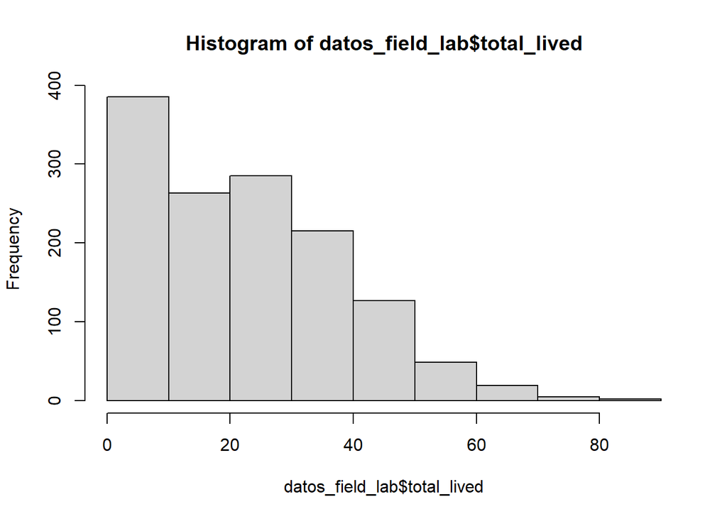

```r
datos_field_lab$`hl/bg` <- factor(datos_field_lab$`hl/bg`,
                                  levels = c("1", "2"),
                                  labels = c("HL", "BG"))
datos_field_lab$location <- factor(datos_field_lab$location,
                                   levels = c("1", "2", "3"),
                                   labels = c("Semi_Urban", "Urban", "Laboratory"))
datos_field$`hl/bg` <- factor(datos_field$`hl/bg`,
                              levels = c("1", "2"),
                              labels = c("HL", "BG"))
datos_field$location <- factor(datos_field$location,
                               levels = c("1", "2"),
                               labels = c("Semi_Urban", "Urban"))

hist(datos_field_lab$total_lived)
```

```r
datos_field <- datos_field %>%
  rename(method = 'hl/bg')
datos_field_lab <- datos_field_lab %>%
  rename(method = `hl/bg`)
```

*Kaplan Meier for categorical variables*

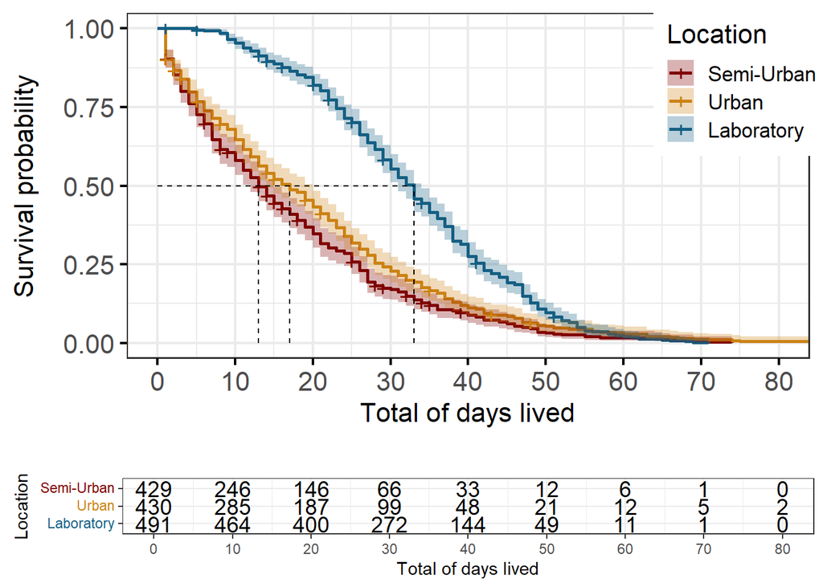

```r
Fig1 <-  survfit(Surv(total_lived, censored) ~ location, data = datos_field_lab, type = "kaplan-meier") %>%
  ggsurvplot(
    surv.median.line = "hv",
    legend.title = "Location",
    legend.labs = c("Semi-Urban", "Urban", "Laboratory"),
    ylab="Survival probability", xlab="Total of days lived",
    legend= c(0.9,0.8),
    surv.plot.heigh = 1.30,
    break.x.by = 10,
    font.tickslab = c(16),
    font.y = c(16),
    font.x = c(16),
    conf.int = TRUE,
    risk.table = TRUE,
    tables.col = "black",
    risk.table.pos="out",
    risk.table.title="",
    risk.table.fontsize = 4.75,
    font.family = "Lato",
    tables.height = 0.25,
    tables.theme = theme_bw(),
    palette =c("#800000FF", "#CC8214FF", "#155F83FF"),
    ggtheme = theme_bw((base_size=16)))

Fig1
```

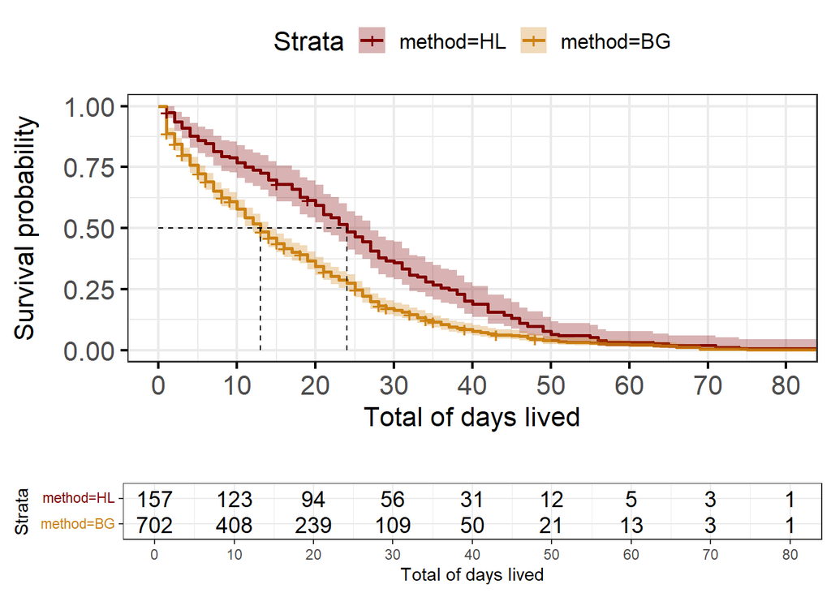

```r
Fig2 <-  survfit(Surv(total_lived, censored) ~ method, data = datos_field_lab, type = "kaplan-meier") %>%
  ggsurvplot(
    surv.median.line = "hv",
    ylab="Survival probability", xlab="Total of days lived",
    surv.plot.heigh = 1.30,
    break.x.by = 10,
    font.tickslab = c(16),
    font.y = c(16),
    font.x = c(16),
    conf.int = TRUE,
    risk.table = TRUE,
    tables.col = "black",
    risk.table.pos="out",
    risk.table.title="",
    risk.table.fontsize = 4.75,
    font.family = "Lato",
    tables.height = 0.25,
    tables.theme = theme_bw(),
    palette =c("#800000FF", "#CC8214FF"),
    ggtheme = theme_bw((base_size=16)))

Fig2
```

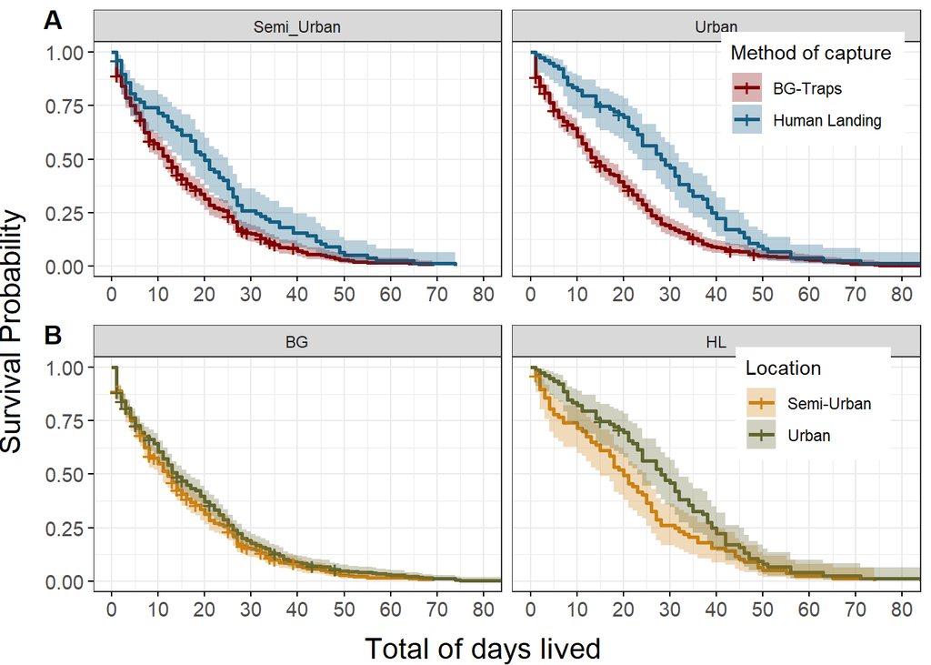

```r
#This is a plot about the survival between locations by method of capture#
Fig3<- survfit(Surv(total_lived, censored)~ method + location, datos_field_lab, conf.type="log-log")%>%
  ggsurvplot(
    conf.int = T,
    facet.by = "location",
    legend.title = "Method of capture",
    short.panel.labs = T,
    legend.labs = c("BG-Traps", "Human Landing"),
    ylab="Survival probability", xlab="Total of days lived ",
    legend= c(0.87,0.8),
    surv.plot.heigh = 1.30,
    break.x.by = 10,
    font.tickslab = c(11),
    font.y = c(14),
    font.x = c(14),
    font.family = "Lato",
    palette =c("#800000FF", "#155F83FF"),
    ggtheme = theme_bw(base_size=11),
  )

#This is a plot about the survival between same methods of capture in the different locations#
Fig4<- survfit(Surv(total_lived, censored)~ location + method, datos_field_lab, conf.type="log-log")%>%
  ggsurvplot(
    conf.int = T,
    facet.by = "method",
    legend.title = "Location",
    short.panel.labs = T,
    legend.labs = c("Semi-Urban", "Urban"),
    ylab="Survival probability", xlab="Total of days lived",
    legend= c(0.87,0.8),
    surv.plot.heigh = 1.30,
    break.x.by = 10,
    font.tickslab = c(11),
    font.y = c(14),
    font.x = c(14),
    font.family = "Lato",
    palette =c("#CC8214FF", "#616530FF"),
    ggtheme = theme_bw(base_size=11),
  )

FIG5<- ggarrange(Fig3 + rremove("ylab") + rremove("xlab"), Fig4 + rremove("ylab") + rremove("xlab"), nrow = 2, labels =c("A", "B"))

library(grid)

FIGURA5COMPLETE<- annotate_figure(FIG5, left = textGrob("Survival Probability", rot = 90, vjust = 0.1, gp = gpar(cex = 1.3)),
                                  bottom = textGrob("Total of days lived", gp = gpar(cex = 1.3)))
FIGURA5COMPLETE
```

*Cumulative hazard*

```r
survloc <- survfit(Surv(total_lived, censored) ~ location, datos_field_lab)
R <- survloc %>% fortify %>% group_by(strata) %>% mutate(CumHaz = cumsum(n.event/n.risk))
print(R, 60)
```

```
## # A tibble: 183 x 10
## # Groups:   strata [3]
##     time n.risk n.event n.censor  surv std.err upper lower strata     CumHaz
##    <dbl>  <dbl>   <dbl>    <dbl> <dbl>   <dbl> <dbl> <dbl> <fct>       <dbl>
##  1     1    429      41       15 0.904  0.0157 0.933 0.877 Semi_Urban 0.0956
##  2     2    373      21        0 0.854  0.0202 0.888 0.820 Semi_Urban 0.152
##  3     3    352      22        0 0.800  0.0244 0.839 0.763 Semi_Urban 0.214
##  4     4    330      16        0 0.761  0.0274 0.803 0.722 Semi_Urban 0.263
##  5     5    314      14        0 0.727  0.0300 0.771 0.686 Semi_Urban 0.307
##  6     6    300      12        2 0.698  0.0322 0.744 0.656 Semi_Urban 0.347
##  7     7    286      21        0 0.647  0.0363 0.695 0.603 Semi_Urban 0.421
##  8     8    265      13        1 0.615  0.0389 0.664 0.570 Semi_Urban 0.470
##  9     9    251       4        1 0.606  0.0397 0.654 0.560 Semi_Urban 0.486
## 10    10    246      10        0 0.581  0.0418 0.630 0.535 Semi_Urban 0.527
## # ... with 173 more rows
```

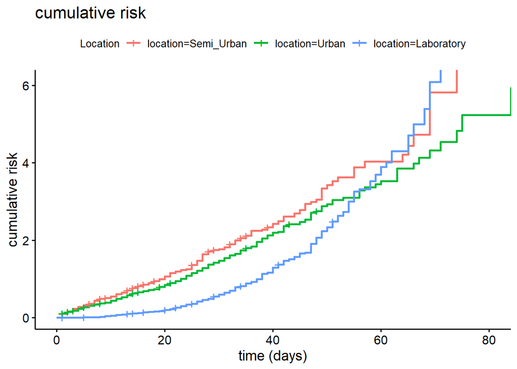

```r
ggsurvplot(survloc, fun = "cumhaz", xlab = "time (days)", censor = T,
           ylab = "cumulative risk", title = "cumulative risk", legend.title = "Location")
```

```r
survmet <- survfit(Surv(total_lived, censored) ~ method, datos_field_lab)
S <- survmet %>% fortify %>% group_by(strata) %>% mutate(CumHaz = cumsum(n.event/n.risk))
print(S, 60)
```

```
## # A tibble: 119 x 10
## # Groups:   strata [2]
##     time n.risk n.event n.censor  surv std.err upper lower strata CumHaz
##    <dbl>  <dbl>   <dbl>    <dbl> <dbl>   <dbl> <dbl> <dbl> <fct>   <dbl>
##  1     1    157       4        1 0.975  0.0129 0.999 0.950 HL     0.0255
##  2     2    152       6        0 0.936  0.0209 0.975 0.898 HL     0.0650
##  3     3    146       4        0 0.910  0.0251 0.956 0.867 HL     0.0923
##  4     4    142       5        0 0.878  0.0298 0.931 0.829 HL     0.128
##  5     5    137       3        0 0.859  0.0324 0.915 0.806 HL     0.149
##  6     6    134       2        0 0.846  0.0341 0.905 0.792 HL     0.164
##  7     7    132       5        0 0.814  0.0382 0.878 0.755 HL     0.202
##  8     8    127       3        0 0.795  0.0406 0.861 0.734 HL     0.226
##  9     9    124       1        0 0.789  0.0414 0.855 0.727 HL     0.234
## 10    10    123       3        0 0.769  0.0438 0.838 0.706 HL     0.258
## # ... with 109 more rows
```

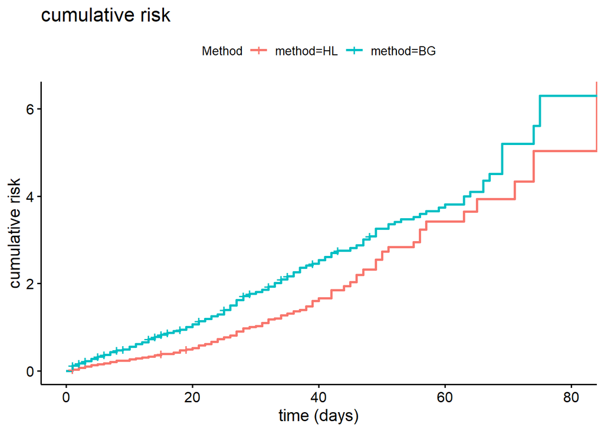

```r
ggsurvplot(survmet, fun = "cumhaz", xlab = "time (days)", censor = T,
           ylab = "cumulative risk", title = "cumulative risk", legend.title = "Method")
```

**COX REGRESSION MODELS**

We take first the categorical variables.

```r
#first, with the 3 Locations
cox_3loc<- coxph(Surv(total_lived, censored) ~ location, data= datos_field_lab)
summary(cox_3loc)
```

```
## Call:
## coxph(formula = Surv(total_lived, censored) ~ location, data = datos_field_lab)
##
##   n= 1350, number of events= 1274
##
##                        coef exp(coef) se(coef)      z Pr(>|z|)
## locationUrban      -0.22899   0.79534  0.07067  -3.24  0.00119 **
## locationLaboratory -0.80786   0.44581  0.06943 -11.64  < 2e-16 ***
## ---
## Signif. codes:  0 '***' 0.001 '**' 0.01 '*' 0.05 '.' 0.1 ' ' 1
##
##                    exp(coef) exp(-coef) lower .95 upper .95
## locationUrban         0.7953      1.257    0.6925    0.9135
## locationLaboratory    0.4458      2.243    0.3891    0.5108
##
## Concordance= 0.642  (se = 0.007 )
## Likelihood ratio test= 149.5  on 2 df,   p=<2e-16
## Wald test            = 146.4  on 2 df,   p=<2e-16
## Score (logrank) test = 152.3  on 2 df,   p=<2e-16
```

In this first model, it takes as a reference the Semi Urban area (location =1); location Urban (Palafolls) has a hazard ratio of 0.79534 (<1), which means that being in the Urban location reduces 0.79534 the risk of death. CI 95% is [0.6925-0.9135], which means association at 5% level. In Laboratory location occurs the same; being in the Laboratory reduces the risk of death compared to the reference in 0.44581. We see that is even more significative than the Urban Location. CI 95% is [0.3891-0.5108], which means association at 5% level. Conclussion: in Semi Urban location we have more risk of death than in Urban location or Laboratory.

```r
#Field
coxmet<- coxph(Surv(total_lived, censored) ~ method, data= datos_field)
summary(coxmet)
```

```
## Call:
## coxph(formula = Surv(total_lived, censored) ~ method, data = datos_field)
##
##   n= 859, number of events= 810
##
##             coef exp(coef) se(coef)     z Pr(>|z|)
## methodBG 0.45042   1.56897  0.09025 4.991 6.02e-07 ***
## ---
## Signif. codes:  0 '***' 0.001 '**' 0.01 '*' 0.05 '.' 0.1 ' ' 1
##
##          exp(coef) exp(-coef) lower .95 upper .95
## methodBG     1.569     0.6374     1.315     1.873
##
## Concordance= 0.55  (se = 0.008 )
## Likelihood ratio test= 27.16  on 1 df,   p=2e-07
## Wald test            = 24.91  on 1 df,   p=6e-07
## Score (logrank) test = 25.31  on 1 df,   p=5e-07
```

```r
coxlocfield<- coxph(Surv(total_lived, censored) ~ location, data= datos_field)
summary(coxlocfield)
```

```
## Call:
## coxph(formula = Surv(total_lived, censored) ~ location, data = datos_field)
##
##   n= 859, number of events= 810
##
##                  coef exp(coef) se(coef)     z Pr(>|z|)
## locationUrban -0.1824    0.8333   0.0707 -2.58  0.00989 **
## ---
## Signif. codes:  0 '***' 0.001 '**' 0.01 '*' 0.05 '.' 0.1 ' ' 1
##
##               exp(coef) exp(-coef) lower .95 upper .95
## locationUrban    0.8333        1.2    0.7255    0.9571
##
## Concordance= 0.525  (se = 0.01 )
## Likelihood ratio test= 6.64  on 1 df,   p=0.01
## Wald test            = 6.65  on 1 df,   p=0.01
## Score (logrank) test = 6.67  on 1 df,   p=0.01
```

*Cox model of method of capture* (only data from the field, since there’s no method of capture in the lab); it takes HL as reference of the method of capture; we see that BG method has a hazard ratio of 1.56897, which means that being captured for a BG-trap instead of HL increases the risk of death 1.56897 times. We see that is very significative. CI 95% is [1.315-1.873], which not includes 1, so there’s a significative association at 5% level.

*Cox model of location in the field*; it takes SemiUrban area as reference. We see that Urban area has a hazard ratio of 0.8333, which means that being in the Urban area instead of SemiUrban reduces the risk of death 0.8333. It is significative. CI 95% is [0.7255-0.9571], which not includes 1, so there’s a significative association at 5% level.

**COX REGRESSION WITH CONTINUOUS VARIABLES: WEATHER**

Now we are going to prepare the dataframe: 1. We need to have as much rows as days lived for each mosquito, to be able to analyze the fluctuation of the weather in all their lives, not only the day of start. 2. We need to calculate photoperiod.

With this, we will start doing Cox models with all the variables, categorical and continuous.

```r
df <- read_excel("datos_field.xlsx", col_types = c("numeric",
                                                   "date", "date", "numeric", "numeric",
                                                   "numeric", "numeric", "numeric", "numeric",
                                                   "numeric", "numeric", "numeric", "numeric"))
clima <- read_excel("clima_field.xlsx", col_types = c("date",
                                                      "numeric", "numeric", "numeric", "numeric",
                                                      "numeric", "numeric", "numeric"))

new_df <- df[0, ] # this also works, mantaining object structure (data.frame) and column names

id <- seq_len(nrow(df)) # since there are duplicated ID, we iterate by row

df$start_date <- as.Date(df$start_date, format = '%Y-%m-%d')

df$start_date <- as.Date(df$start_date, format = '%Y-%m-%d')
clima$start_date <- as.character(as.Date(clima$start_date, format = '%Y-%m-%d'))

new_df <- do.call('rbind', lapply(seq_len(nrow(df)), function(id){
  tmp <- do.call('rbind', replicate(df$total_lived[id],
                                    df[id, ], simplify = FALSE))
  tmp$start_date <- format(seq(tmp$start_date[1], by = 'day',
                               length.out = nrow(tmp)), '%Y-%m-%d')
  tmp
}))

vars <- c('maxtemperature', 'meantemperature', 'mintemperature', 'maxrh', 'minrh', 'meanrh')
for(d in unique(clima$start_date)){
  new_df[new_df$start_date == d & new_df$location == 1, vars] <-
    clima[clima$start_date == d & clima$location == 1, vars]
  new_df[new_df$start_date == d & new_df$location == 2, vars] <-
    clima[clima$start_date == d & clima$location == 2, vars]
}


#we add photoperiod
library(meteor)
photoperiod <- photoperiod(152:334,  41.6833)
photoperiod <- as.data.frame(photoperiod)
values = seq(from = as.Date("2021-06-01"), to = as.Date("2021-11-30"), by = 'day')
photoperiod$dates <- values
photoperiod$dates <- as.character(as.Date(photoperiod$dates, format = '%Y-%m-%d'))
new_df$start_date <- as.character(as.Date(new_df$start_date, format = '%Y-%m-%d'))

str(photoperiod)
```

```
## 'data.frame':    183 obs. of  2 variables:
##  $ photoperiod: num  15 15 15 15 15.1 ...
##  $ dates      : chr  "2021-06-01" "2021-06-02" "2021-06-03" "2021-06-04" ...
```

```r
new_df[ , 'photoperiod'] <- 0 # new column called photoperiod
vars2 <- c('photoperiod')
for(d in unique(photoperiod$dates)){
  new_df[new_df$start_date == d,vars2] <-
    photoperiod[photoperiod$dates == d, vars2]
}

new_df$`hl/bg` <- factor(new_df$`hl/bg`,
                         levels = c("1", "2"),
                         labels = c("HL", "BG"))
new_df$location <- factor(new_df$location,
                          levels = c("1", "2"),
                          labels = c("Semi_Urban", "Urban"))


new_df <- new_df %>%
  rename(method = 'hl/bg')
```

First of all, as we want to be sure that the categorical variables don’t influence the others, we want to separate the dataframe in 4 parts: 1) Only data from BG-traps 2) Only data from HL 3) Only data from Semi-Urban area 4) Only data from Urban area

Once we do this, we will check one by one which variables are affecting (and how) to the survival. Then, we will add them into a complete model and we will see if they change.

```r
data_hl<- subset(new_df, method=="HL")
data_bg<- subset(new_df, method=="BG")
data_semiu<- subset(new_df, location=="Semi_Urban")
data_urb<- subset(new_df, location=="Urban")
```

###BG TRAPS###

```r
modelobg_tmin<- coxph(Surv(total_lived, censored) ~ mintemperature, data= data_bg)
summary(modelobg_tmin)
```

```
## Call:
## coxph(formula = Surv(total_lived, censored) ~ mintemperature,
##     data = data_bg)
##
##   n= 11212, number of events= 10634
##
##                    coef exp(coef) se(coef)     z Pr(>|z|)
## mintemperature 0.031202  1.031694 0.002412 12.94   <2e-16 ***
## ---
## Signif. codes:  0 '***' 0.001 '**' 0.01 '*' 0.05 '.' 0.1 ' ' 1
##
##                exp(coef) exp(-coef) lower .95 upper .95
## mintemperature     1.032     0.9693     1.027     1.037
##
## Concordance= 0.54  (se = 0.003 )
## Likelihood ratio test= 172.9  on 1 df,   p=<2e-16
## Wald test            = 167.3  on 1 df,   p=<2e-16
## Score (logrank) test = 167.6  on 1 df,   p=<2e-16
```

As we can see, the variable *mintemperature* affects negatively survival (hazard ratio = 1.031694). For each increment in 1 ud (1 degree in this case), the risk of death increases 1.031694. CI95% is [1.027-1.037], which means association at 5% level. p-value <0.05.

```r
modelobg_tmean<- coxph(Surv(total_lived, censored) ~ meantemperature, data= data_bg)
summary(modelobg_tmean)
```

```
## Call:
## coxph(formula = Surv(total_lived, censored) ~ meantemperature,
##     data = data_bg)
##
##   n= 11212, number of events= 10634
##
##                     coef exp(coef) se(coef)     z Pr(>|z|)
## meantemperature 0.036371  1.037040 0.002521 14.43   <2e-16 ***
## ---
## Signif. codes:  0 '***' 0.001 '**' 0.01 '*' 0.05 '.' 0.1 ' ' 1
##
##                 exp(coef) exp(-coef) lower .95 upper .95
## meantemperature     1.037     0.9643     1.032     1.042
##
## Concordance= 0.549  (se = 0.003 )
## Likelihood ratio test= 215.7  on 1 df,   p=<2e-16
## Wald test            = 208.2  on 1 df,   p=<2e-16
## Score (logrank) test = 208.7  on 1 df,   p=<2e-16
```

*Mean temperature* also affects negatively (hazard ratio = 1.037040). For each increment in 1 ud (1 degree), risk of death increases 1.037040. CI95% is [1.032-1.042], which means association at 5% level. p-value <0.05.

```r
modelobg_tmax <- coxph(Surv(total_lived, censored) ~ maxtemperature, data= data_bg)
summary(modelobg_tmax)
```

```
## Call:
## coxph(formula = Surv(total_lived, censored) ~ maxtemperature,
##     data = data_bg)
##
##   n= 11212, number of events= 10634
##
##                    coef exp(coef) se(coef)     z Pr(>|z|)
## maxtemperature 0.033679  1.034253 0.002429 13.87   <2e-16 ***
## ---
## Signif. codes:  0 '***' 0.001 '**' 0.01 '*' 0.05 '.' 0.1 ' ' 1
##
##                exp(coef) exp(-coef) lower .95 upper .95
## maxtemperature     1.034     0.9669     1.029     1.039
##
## Concordance= 0.545  (se = 0.003 )
## Likelihood ratio test= 196.6  on 1 df,   p=<2e-16
## Wald test            = 192.3  on 1 df,   p=<2e-16
## Score (logrank) test = 192.5  on 1 df,   p=<2e-16
```

*maxtemperature* affects negatively (hazard ratio = 1.034253). For each increment in 1 ud (1 degree), risk of death increases 1.034253. CI95% is [1.029-1.039], which doesn´t include 1, so there’s signifificant association at 5% level. p-value <0.05.

Now we are going to play with interactions between temperatures:

```r
modelobg_meanmax <- coxph(Surv(total_lived, censored) ~ meantemperature + maxtemperature, data= data_bg)
summary(modelobg_meanmax)
```

```
## Call:
## coxph(formula = Surv(total_lived, censored) ~ meantemperature +
##     maxtemperature, data = data_bg)
##
##   n= 11212, number of events= 10634
##
##                     coef exp(coef) se(coef)     z Pr(>|z|)
## meantemperature 0.033072  1.033624 0.007544 4.384 1.16e-05 ***
## maxtemperature  0.003397  1.003403 0.007322 0.464    0.643
## ---
## Signif. codes:  0 '***' 0.001 '**' 0.01 '*' 0.05 '.' 0.1 ' ' 1
##
##                 exp(coef) exp(-coef) lower .95 upper .95
## meantemperature     1.034     0.9675    1.0185     1.049
## maxtemperature      1.003     0.9966    0.9891     1.018
##
## Concordance= 0.549  (se = 0.003 )
## Likelihood ratio test= 215.9  on 2 df,   p=<2e-16
## Wald test            = 208.5  on 2 df,   p=<2e-16
## Score (logrank) test = 209.1  on 2 df,   p=<2e-16
```

```r
modelobg_meanmax2 <- coxph(Surv(total_lived, censored) ~ meantemperature + maxtemperature + meantemperature:maxtemperature, data= data_bg)
summary(modelobg_meanmax2)
```

```
## Call:
## coxph(formula = Surv(total_lived, censored) ~ meantemperature +
##     maxtemperature + meantemperature:maxtemperature, data = data_bg)
##
##   n= 11212, number of events= 10634
##
##                                      coef  exp(coef)   se(coef)      z Pr(>|z|)
## meantemperature                -0.0343642  0.9662195  0.0119418 -2.878  0.00401
## maxtemperature                 -0.0762282  0.9266047  0.0133484 -5.711 1.13e-08
## meantemperature:maxtemperature  0.0035162  1.0035223  0.0004907  7.166 7.73e-13
##
## meantemperature                **
## maxtemperature                 ***
## meantemperature:maxtemperature ***
## ---
## Signif. codes:  0 '***' 0.001 '**' 0.01 '*' 0.05 '.' 0.1 ' ' 1
##
##                                exp(coef) exp(-coef) lower .95 upper .95
## meantemperature                   0.9662     1.0350    0.9439    0.9891
## maxtemperature                    0.9266     1.0792    0.9027    0.9512
## meantemperature:maxtemperature    1.0035     0.9965    1.0026    1.0045
##
## Concordance= 0.548  (se = 0.003 )
## Likelihood ratio test= 265.2  on 3 df,   p=<2e-16
## Wald test            = 270.6  on 3 df,   p=<2e-16
## Score (logrank) test = 272.3  on 3 df,   p=<2e-16
```

When we put in a model *meantemperature* and *maxtemperature*, maxtemperature becomes no significative. Both have negative effects in survival as we can see in their hazard ratio. When we add a interaction between these two variables, we see that *maxtemperature* and *meantemperature* change completely their hazard ratio (now, an increase in 1 degree reduces risk of death!! it has no sense for maximum temperatures…). The interaction between them shows a hazard ratio >1 (increase in the risk of death).

We will start now with the variable “RH” (Relative Humidity).

```r
#1
modelobg_rhmin<- coxph(Surv(total_lived, censored) ~ minrh, data= data_bg)
summary(modelobg_rhmin)
```

```
## Call:
## coxph(formula = Surv(total_lived, censored) ~ minrh, data = data_bg)
##
##   n= 11212, number of events= 10634
##
##             coef  exp(coef)   se(coef)      z Pr(>|z|)
## minrh -0.0020239  0.9979782  0.0006926 -2.922  0.00348 **
## ---
## Signif. codes:  0 '***' 0.001 '**' 0.01 '*' 0.05 '.' 0.1 ' ' 1
##
##       exp(coef) exp(-coef) lower .95 upper .95
## minrh     0.998      1.002    0.9966    0.9993
##
## Concordance= 0.518  (se = 0.003 )
## Likelihood ratio test= 8.54  on 1 df,   p=0.003
## Wald test            = 8.54  on 1 df,   p=0.003
## Score (logrank) test = 8.54  on 1 df,   p=0.003
```

```r
#2
modelobg_rhmean<- coxph(Surv(total_lived, censored) ~ meanrh, data= data_bg)
summary(modelobg_rhmean)
```

```
## Call:
## coxph(formula = Surv(total_lived, censored) ~ meanrh, data = data_bg)
##
##   n= 11212, number of events= 10634
##
##              coef  exp(coef)   se(coef)      z Pr(>|z|)
## meanrh -0.0032446  0.9967607  0.0009076 -3.575  0.00035 ***
## ---
## Signif. codes:  0 '***' 0.001 '**' 0.01 '*' 0.05 '.' 0.1 ' ' 1
##
##        exp(coef) exp(-coef) lower .95 upper .95
## meanrh    0.9968      1.003     0.995    0.9985
##
## Concordance= 0.517  (se = 0.003 )
## Likelihood ratio test= 12.74  on 1 df,   p=4e-04
## Wald test            = 12.78  on 1 df,   p=4e-04
## Score (logrank) test = 12.78  on 1 df,   p=4e-04
```

```r
#3
modelobg_rhmax<- coxph(Surv(total_lived, censored) ~ maxrh, data= data_bg)
summary(modelobg_rhmax)
```

```
## Call:
## coxph(formula = Surv(total_lived, censored) ~ maxrh, data = data_bg)
##
##   n= 11212, number of events= 10634
##
##            coef exp(coef)  se(coef)      z Pr(>|z|)
## maxrh -0.002641  0.997363  0.001117 -2.364   0.0181 *
## ---
## Signif. codes:  0 '***' 0.001 '**' 0.01 '*' 0.05 '.' 0.1 ' ' 1
##
##       exp(coef) exp(-coef) lower .95 upper .95
## maxrh    0.9974      1.003    0.9952    0.9995
##
## Concordance= 0.508  (se = 0.003 )
## Likelihood ratio test= 5.54  on 1 df,   p=0.02
## Wald test            = 5.59  on 1 df,   p=0.02
## Score (logrank) test = 5.59  on 1 df,   p=0.02
```

```r
#4
modelobg_rhminmax<- coxph(Surv(total_lived, censored) ~ maxrh + minrh, data= data_bg)
summary(modelobg_rhminmax)
```

```
## Call:
## coxph(formula = Surv(total_lived, censored) ~ maxrh + minrh,
##     data = data_bg)
##
##   n= 11212, number of events= 10634
##
##             coef  exp(coef)   se(coef)      z Pr(>|z|)
## maxrh -0.0006827  0.9993176  0.0015656 -0.436   0.6628
## minrh -0.0017298  0.9982717  0.0009674 -1.788   0.0738 .
## ---
## Signif. codes:  0 '***' 0.001 '**' 0.01 '*' 0.05 '.' 0.1 ' ' 1
##
##       exp(coef) exp(-coef) lower .95 upper .95
## maxrh    0.9993      1.001    0.9963     1.002
## minrh    0.9983      1.002    0.9964     1.000
##
## Concordance= 0.517  (se = 0.003 )
## Likelihood ratio test= 8.73  on 2 df,   p=0.01
## Wald test            = 8.74  on 2 df,   p=0.01
## Score (logrank) test = 8.74  on 2 df,   p=0.01
```

```r
#5
modelobg_rhmeanmin<- coxph(Surv(total_lived, censored) ~ meanrh + minrh, data= data_bg)
summary(modelobg_rhmeanmin)
```

```
## Call:
## coxph(formula = Surv(total_lived, censored) ~ meanrh + minrh,
##     data = data_bg)
##
##   n= 11212, number of events= 10634
##
##             coef exp(coef)  se(coef)      z Pr(>|z|)
## meanrh -0.006696  0.993326  0.002735 -2.448   0.0144 *
## minrh   0.002792  1.002796  0.002089  1.336   0.1814
## ---
## Signif. codes:  0 '***' 0.001 '**' 0.01 '*' 0.05 '.' 0.1 ' ' 1
##
##        exp(coef) exp(-coef) lower .95 upper .95
## meanrh    0.9933     1.0067    0.9880    0.9987
## minrh     1.0028     0.9972    0.9987    1.0069
##
## Concordance= 0.513  (se = 0.003 )
## Likelihood ratio test= 14.53  on 2 df,   p=7e-04
## Wald test            = 14.66  on 2 df,   p=7e-04
## Score (logrank) test = 14.66  on 2 df,   p=7e-04
```

```r
#6
modelobg_rhmeannmax<- coxph(Surv(total_lived, censored) ~ maxrh + meanrh, data= data_bg)
summary(modelobg_rhmeannmax)
```

```
## Call:
## coxph(formula = Surv(total_lived, censored) ~ maxrh + meanrh,
##     data = data_bg)
##
##   n= 11212, number of events= 10634
##
##             coef exp(coef)  se(coef)      z Pr(>|z|)
## maxrh   0.003306  1.003311  0.002234  1.480  0.13890
## meanrh -0.005567  0.994449  0.001809 -3.077  0.00209 **
## ---
## Signif. codes:  0 '***' 0.001 '**' 0.01 '*' 0.05 '.' 0.1 ' ' 1
##
##        exp(coef) exp(-coef) lower .95 upper .95
## maxrh     1.0033     0.9967    0.9989     1.008
## meanrh    0.9944     1.0056    0.9909     0.998
##
## Concordance= 0.52  (se = 0.003 )
## Likelihood ratio test= 14.92  on 2 df,   p=6e-04
## Wald test            = 14.96  on 2 df,   p=6e-04
## Score (logrank) test = 14.96  on 2 df,   p=6e-04
```

```r
#7
modelobg_allrh<- coxph(Surv(total_lived, censored) ~ maxrh + meanrh + minrh, data= data_bg)
summary(modelobg_allrh)
```

```
## Call:
## coxph(formula = Surv(total_lived, censored) ~ maxrh + meanrh +
##     minrh, data = data_bg)
##
##   n= 11212, number of events= 10634
##
##             coef exp(coef)  se(coef)      z Pr(>|z|)
## maxrh   0.011255  1.011319  0.003198  3.520 0.000432 ***
## meanrh -0.023981  0.976304  0.005627 -4.262 2.03e-05 ***
## minrh   0.010377  1.010431  0.003011  3.446 0.000569 ***
## ---
## Signif. codes:  0 '***' 0.001 '**' 0.01 '*' 0.05 '.' 0.1 ' ' 1
##
##        exp(coef) exp(-coef) lower .95 upper .95
## maxrh     1.0113     0.9888    1.0050    1.0177
## meanrh    0.9763     1.0243    0.9656    0.9871
## minrh     1.0104     0.9897    1.0045    1.0164
##
## Concordance= 0.524  (se = 0.003 )
## Likelihood ratio test= 26.84  on 3 df,   p=6e-06
## Wald test            = 27.2  on 3 df,   p=5e-06
## Score (logrank) test = 27.2  on 3 df,   p=5e-06
```

In **model 1** (only minimum RH is added) we get a hazard ratio of 0.9979 (p-value <0.05). That means that an increase of 1 in min RH produces a decrease in the risk of death of 0.9979782. CI95% [0.9966-0.9993] doesn’t include 1, so there is significative association at 5% level.

In **model 2** (only mean RH is added) we get a hazard ratio of 0.9968 (p-value<0.05). An increase of 1 ud in meanRH produces a decrease in the risk of death of 0.9968. CI95%[0.995-0.9985]; it doesn’t include 1 (barely) so there is significative association at 5% level.

In **model 3** (only max RH is added) we get a hazard ratio of 0.997363 (p-value <0.05). An increase of 1 ud in max Rh produces a decrease in the risk of death of 0.997363. CI95% [0.9952-0.9995]; it doesn’t include 1, so there is significative association at 5% level.

In **model 4** (we put maxrh and minrh in the model) we get a hazard ratio of 0.9993 in maxrh and 0.9982 in minrh. None of them are significative (in minrh, pvalue very close to be significant). In both of them, CI95% includes 1, so there’s no significant association at 5% level.

In **model 5** (we put meanrh and minrh) we obtain a hazard ratio of 0.993326 in meanrh and 1.002796 in minrh. We see here that now minrh has a coefficient >1, but it isn’t significative (p-value > 0.05). Also the CI95% in minrh includes 1, so there’s no significant association at 5% level when this 2 variables are together.

In **model 6** (we put maxrh and meanrh), we obtain a hazard ratio of 0.994449 in meanrh and 1.003311 in maxrh. We see that now maxrh has a coefficient >1 , but it isn’t significative (p-value >0.05). Also the CI95% in maxrh includes 1, so there’s no significant association at 5% level when this 2 variables are together.

In **model 7** (we put all the rh); the hazard ratio of maxrh is >1 and significative here (1.011319, p-value <0.05). Also minrh is >1 and significative when the 3 variables are together (1.010431, p-value <0.05). MeanRH remains <1 and significative.

**It seems like meanRH is influencing in some way with minRH and maxRH**

We are going to put the last “weather” variable, which is photoperiod.

```r
modelobg_photop<- coxph(Surv(total_lived, censored) ~ photoperiod, data= data_bg)
summary(modelobg_photop)
```

```
## Call:
## coxph(formula = Surv(total_lived, censored) ~ photoperiod, data = data_bg)
##
##   n= 11212, number of events= 10634
##
##                 coef exp(coef) se(coef)     z Pr(>|z|)
## photoperiod 0.151321  1.163370 0.007631 19.83   <2e-16 ***
## ---
## Signif. codes:  0 '***' 0.001 '**' 0.01 '*' 0.05 '.' 0.1 ' ' 1
##
##             exp(coef) exp(-coef) lower .95 upper .95
## photoperiod     1.163     0.8596     1.146     1.181
##
## Concordance= 0.561  (se = 0.003 )
## Likelihood ratio test= 401.3  on 1 df,   p=<2e-16
## Wald test            = 393.3  on 1 df,   p=<2e-16
## Score (logrank) test = 389.7  on 1 df,   p=<2e-16
```

We obtain here that photoperiod has a hazard ratio of 1.163370 (and a p-value <0.05). It means that when photoperiod increases 1 ud (in this case I understand that this “increase” is the advance of the photoperiod along the weeks lived by the mosquito - that is, the decrease of the light hours per day), the risk of death increases 1.163370. CI95% is [1.146-1.181], which doesn’t include 1, so there’s significative association at 5% level.

```r
modelobg_min <- coxph(Surv(total_lived, censored) ~ mintemperature + minrh + photoperiod, data= data_bg)
summary(modelobg_min)
```

```
## Call:
## coxph(formula = Surv(total_lived, censored) ~ mintemperature +
##     minrh + photoperiod, data = data_bg)
##
##   n= 11212, number of events= 10634
##
##                      coef  exp(coef)   se(coef)      z Pr(>|z|)
## mintemperature -0.0198799  0.9803164  0.0045923 -4.329  1.5e-05 ***
## minrh           0.0019848  1.0019867  0.0008579  2.313   0.0207 *
## photoperiod     0.2026858  1.2246876  0.0141936 14.280  < 2e-16 ***
## ---
## Signif. codes:  0 '***' 0.001 '**' 0.01 '*' 0.05 '.' 0.1 ' ' 1
##
##                exp(coef) exp(-coef) lower .95 upper .95
## mintemperature    0.9803     1.0201    0.9715    0.9892
## minrh             1.0020     0.9980    1.0003    1.0037
## photoperiod       1.2247     0.8165    1.1911    1.2592
##
## Concordance= 0.56  (se = 0.003 )
## Likelihood ratio test= 420.1  on 3 df,   p=<2e-16
## Wald test            = 417.3  on 3 df,   p=<2e-16
## Score (logrank) test = 406.5  on 3 df,   p=<2e-16
```

```r
modelobg_max <- coxph(Surv(total_lived, censored) ~ maxtemperature + maxrh + photoperiod, data= data_bg)
summary(modelobg_max)
```

```
## Call:
## coxph(formula = Surv(total_lived, censored) ~ maxtemperature +
##     maxrh + photoperiod, data = data_bg)
##
##   n= 11212, number of events= 10634
##
##                      coef  exp(coef)   se(coef)      z Pr(>|z|)
## maxtemperature -0.0255864  0.9747381  0.0045990 -5.564 2.64e-08 ***
## maxrh           0.0002234  1.0002234  0.0011362  0.197    0.844
## photoperiod     0.2193334  1.2452464  0.0144851 15.142  < 2e-16 ***
## ---
## Signif. codes:  0 '***' 0.001 '**' 0.01 '*' 0.05 '.' 0.1 ' ' 1
##
##                exp(coef) exp(-coef) lower .95 upper .95
## maxtemperature    0.9747     1.0259     0.966    0.9836
## maxrh             1.0002     0.9998     0.998    1.0025
## photoperiod       1.2452     0.8031     1.210    1.2811
##
## Concordance= 0.562  (se = 0.003 )
## Likelihood ratio test= 432.4  on 3 df,   p=<2e-16
## Wald test            = 428.1  on 3 df,   p=<2e-16
## Score (logrank) test = 414.7  on 3 df,   p=<2e-16
```

```r
modelobg_mean <-coxph(Surv(total_lived, censored) ~ meantemperature + meanrh + photoperiod, data= data_bg)
summary(modelobg_mean)
```

```
## Call:
## coxph(formula = Surv(total_lived, censored) ~ meantemperature +
##     meanrh + photoperiod, data = data_bg)
##
##   n= 11212, number of events= 10634
##
##                      coef exp(coef)  se(coef)      z Pr(>|z|)
## meantemperature -0.026936  0.973424  0.005385 -5.002 5.68e-07 ***
## meanrh           0.001237  1.001237  0.001016  1.217    0.223
## photoperiod      0.222997  1.249817  0.016493 13.520  < 2e-16 ***
## ---
## Signif. codes:  0 '***' 0.001 '**' 0.01 '*' 0.05 '.' 0.1 ' ' 1
##
##                 exp(coef) exp(-coef) lower .95 upper .95
## meantemperature    0.9734     1.0273    0.9632    0.9838
## meanrh             1.0012     0.9988    0.9992    1.0032
## photoperiod        1.2498     0.8001    1.2101    1.2909
##
## Concordance= 0.56  (se = 0.003 )
## Likelihood ratio test= 427.1  on 3 df,   p=<2e-16
## Wald test            = 424.9  on 3 df,   p=<2e-16
## Score (logrank) test = 411  on 3 df,   p=<2e-16
```

**HUMAN LANDING METHOD**

We will start now with the data of mosquitoes captured by Human Landing method. We will check all the variables one by one, and then we will put them together, as in the previous dataframe with BG-traps.

```r
modelohl_tmin <- coxph(Surv(total_lived, censored) ~ mintemperature, data= data_hl)
summary(modelohl_tmin)
```

```
## Call:
## coxph(formula = Surv(total_lived, censored) ~ mintemperature,
##     data = data_hl)
##
##   n= 3943, number of events= 3908
##
##                    coef exp(coef) se(coef)     z Pr(>|z|)
## mintemperature 0.022034  1.022278 0.004072 5.411 6.27e-08 ***
## ---
## Signif. codes:  0 '***' 0.001 '**' 0.01 '*' 0.05 '.' 0.1 ' ' 1
##
##                exp(coef) exp(-coef) lower .95 upper .95
## mintemperature     1.022     0.9782     1.014      1.03
##
## Concordance= 0.53  (se = 0.006 )
## Likelihood ratio test= 29.75  on 1 df,   p=5e-08
## Wald test            = 29.28  on 1 df,   p=6e-08
## Score (logrank) test = 29.3  on 1 df,   p=6e-08
```

In this model, we see that minimum temperature has a hazard ratio of 1.02278, which means that increments in 1 ud (1 degree) implies a rise in the risk of death of 1.022278. p-value <0.05, which means that is significative. CI95% [1.014-1.03], there’s association at 5% level.

```r
modelohl_tmean <- coxph(Surv(total_lived, censored) ~ meantemperature, data= data_hl)
summary(modelohl_tmean)
```

```
## Call:
## coxph(formula = Surv(total_lived, censored) ~ meantemperature,
##     data = data_hl)
##
##   n= 3943, number of events= 3908
##
##                    coef exp(coef) se(coef)     z Pr(>|z|)
## meantemperature 0.02769   1.02808  0.00438 6.322 2.58e-10 ***
## ---
## Signif. codes:  0 '***' 0.001 '**' 0.01 '*' 0.05 '.' 0.1 ' ' 1
##
##                 exp(coef) exp(-coef) lower .95 upper .95
## meantemperature     1.028     0.9727     1.019     1.037
##
## Concordance= 0.536  (se = 0.006 )
## Likelihood ratio test= 40.83  on 1 df,   p=2e-10
## Wald test            = 39.97  on 1 df,   p=3e-10
## Score (logrank) test = 40.03  on 1 df,   p=3e-10
```

In this model, we see that mean temperature has a hazard ratio of 1.02808, which means that increases in 1 degree produce a rise in the risk of death of 1.02808. p-value <0.05, which is significative. CI95% [1.019-1.037], significative association at 5% level

```r
modelohl_tmax <- coxph(Surv(total_lived, censored) ~ maxtemperature, data= data_hl)
summary(modelohl_tmax)
```

```
## Call:
## coxph(formula = Surv(total_lived, censored) ~ maxtemperature,
##     data = data_hl)
##
##   n= 3943, number of events= 3908
##
##                    coef exp(coef) se(coef)     z Pr(>|z|)
## maxtemperature 0.026294  1.026643 0.004388 5.992 2.07e-09 ***
## ---
## Signif. codes:  0 '***' 0.001 '**' 0.01 '*' 0.05 '.' 0.1 ' ' 1
##
##                exp(coef) exp(-coef) lower .95 upper .95
## maxtemperature     1.027      0.974     1.018     1.036
##
## Concordance= 0.53  (se = 0.006 )
## Likelihood ratio test= 36.61  on 1 df,   p=1e-09
## Wald test            = 35.9  on 1 df,   p=2e-09
## Score (logrank) test = 35.93  on 1 df,   p=2e-09
```

In this model, maximum temperatures have a hazard ratio of 1.026643, which mean that increases in 1 degree in maximum temperatures produce an increase in the risk of death of 1.026643. CI95%[1.018-1.036] indicates significative association at 5% level.

```r
modelohl_tminmax <- coxph(Surv(total_lived, censored) ~ mintemperature + maxtemperature, data= data_hl)
summary(modelohl_tminmax)
```

```
## Call:
## coxph(formula = Surv(total_lived, censored) ~ mintemperature +
##     maxtemperature, data = data_hl)
##
##   n= 3943, number of events= 3908
##
##                    coef exp(coef) se(coef)     z Pr(>|z|)
## mintemperature 0.006650  1.006672 0.006830 0.974  0.33022
## maxtemperature 0.020555  1.020768 0.007349 2.797  0.00516 **
## ---
## Signif. codes:  0 '***' 0.001 '**' 0.01 '*' 0.05 '.' 0.1 ' ' 1
##
##                exp(coef) exp(-coef) lower .95 upper .95
## mintemperature     1.007     0.9934    0.9933     1.020
## maxtemperature     1.021     0.9797    1.0062     1.036
##
## Concordance= 0.533  (se = 0.006 )
## Likelihood ratio test= 37.56  on 2 df,   p=7e-09
## Wald test            = 36.78  on 2 df,   p=1e-08
## Score (logrank) test = 36.83  on 2 df,   p=1e-08
```

When we put together in a model temperature minimum + maximum, both have their hazard ratio >1 (so both of them affect negatively the survival when they increase 1 ud), but minimum temperature has a p-value >0.05, so it isn’t significative. We can see this also in their CI; mintemperature has a confidence interval 95% of [0.9933-1.020] –> it includes 1, so there’s not significative association at 5% level.

```r
modelohl_tmeanmax <- coxph(Surv(total_lived, censored) ~ meantemperature + maxtemperature, data= data_hl)
summary(modelohl_tmeanmax)
```

```
## Call:
## coxph(formula = Surv(total_lived, censored) ~ meantemperature +
##     maxtemperature, data = data_hl)
##
##   n= 3943, number of events= 3908
##
##                    coef exp(coef) se(coef)     z Pr(>|z|)
## meantemperature 0.02582   1.02616  0.01256 2.056   0.0398 *
## maxtemperature  0.00200   1.00200  0.01260 0.159   0.8739
## ---
## Signif. codes:  0 '***' 0.001 '**' 0.01 '*' 0.05 '.' 0.1 ' ' 1
##
##                 exp(coef) exp(-coef) lower .95 upper .95
## meantemperature     1.026     0.9745    1.0012     1.052
## maxtemperature      1.002     0.9980    0.9776     1.027
##
## Concordance= 0.536  (se = 0.006 )
## Likelihood ratio test= 40.85  on 2 df,   p=1e-09
## Wald test            = 39.99  on 2 df,   p=2e-09
## Score (logrank) test = 40.05  on 2 df,   p=2e-09
```

When we put in the model mean and max temperatures, both have still their hazard ratios >1 (they supose a rise in the risk of death when they are increased in 1 ud) but maxtemperature becomes not significative (p-value = 0.8739 // CI95% [0.9776-1.027] –> includes 1).

```r
modelohl_tminmean <- coxph(Surv(total_lived, censored) ~ mintemperature + meantemperature, data= data_hl)
summary(modelohl_tminmean)
```

```
## Call:
## coxph(formula = Surv(total_lived, censored) ~ mintemperature +
##     meantemperature, data = data_hl)
##
##   n= 3943, number of events= 3908
##
##                     coef exp(coef) se(coef)      z Pr(>|z|)
## mintemperature  -0.02765   0.97273  0.01320 -2.094   0.0362 *
## meantemperature  0.05588   1.05747  0.01416  3.947 7.92e-05 ***
## ---
## Signif. codes:  0 '***' 0.001 '**' 0.01 '*' 0.05 '.' 0.1 ' ' 1
##
##                 exp(coef) exp(-coef) lower .95 upper .95
## mintemperature     0.9727     1.0280    0.9479    0.9982
## meantemperature    1.0575     0.9457    1.0285    1.0872
##
## Concordance= 0.535  (se = 0.006 )
## Likelihood ratio test= 45.19  on 2 df,   p=2e-10
## Wald test            = 44.32  on 2 df,   p=2e-10
## Score (logrank) test = 44.37  on 2 df,   p=2e-10
```

When we put in the model minimum and mean temperatures, mintemperature has a hazard ratio of 0.97273, which means that for an increase of 1 ud of temperature min (1 degree), the risk of death decreases 0.97273. Meantemperature still has a hazard ratio >1, which means that increases in meantemperature supose a rise in the risk of death of 1.05747. In both temperatures p-value is <0.05.

```r
modelohl_allt <- coxph(Surv(total_lived, censored) ~ mintemperature + meantemperature + maxtemperature, data= data_hl)
summary(modelohl_allt)
```

```
## Call:
## coxph(formula = Surv(total_lived, censored) ~ mintemperature +
##     meantemperature + maxtemperature, data = data_hl)
##
##   n= 3943, number of events= 3908
##
##                     coef exp(coef) se(coef)      z Pr(>|z|)
## mintemperature  -0.08820   0.91558  0.02431 -3.628 0.000286 ***
## meantemperature  0.18181   1.19939  0.04493  4.046  5.2e-05 ***
## maxtemperature  -0.06874   0.93357  0.02333 -2.946 0.003219 **
## ---
## Signif. codes:  0 '***' 0.001 '**' 0.01 '*' 0.05 '.' 0.1 ' ' 1
##
##                 exp(coef) exp(-coef) lower .95 upper .95
## mintemperature     0.9156     1.0922    0.8730    0.9603
## meantemperature    1.1994     0.8338    1.0983    1.3098
## maxtemperature     0.9336     1.0712    0.8918    0.9773
##
## Concordance= 0.54  (se = 0.005 )
## Likelihood ratio test= 53.89  on 3 df,   p=1e-11
## Wald test            = 53.31  on 3 df,   p=2e-11
## Score (logrank) test = 53.4  on 3 df,   p=2e-11
```

In this model we put the 3 temperatures. It has no much sense because: 1) maxtemperature has a hazard ratio <1 (0.93357); this means that each increase in 1 ud in the maxtemperature produces a decrease in the risk of death of 0.93357. High temperatures have a negative effect in survival, so if maximum temperatures (that are naturally high) increase more, survival should be affected negatively! 2) meantemperature has a hazard ratio of 1.19939 (increase in 1 degree suposes a rise in the risk of death of 1.19939). It could have sense (specially in summer months, where mean temperature is high), but not in this case: if increases in the maximum temperatures don’t affect survival negatively, why mean temperature affects positively?? 3) Mintemperature has a hazard ratio of 0.91558, which is <1. It makes more sense to me, because (specially in autumn) minimum temperatures can be very low in some months and it can affect negatively the survival. Because of this, I can understand that increments in each 1 degree can reduce the risk of death 0.91558!

*Photoperiod*

```r
modelohl_ph <- coxph(Surv(total_lived, censored) ~ photoperiod, data= data_hl)
summary(modelohl_ph)
```

```
## Call:
## coxph(formula = Surv(total_lived, censored) ~ photoperiod, data = data_hl)
##
##   n= 3943, number of events= 3908
##
##                coef exp(coef) se(coef)     z Pr(>|z|)
## photoperiod 0.14331   1.15408  0.01413 10.14   <2e-16 ***
## ---
## Signif. codes:  0 '***' 0.001 '**' 0.01 '*' 0.05 '.' 0.1 ' ' 1
##
##             exp(coef) exp(-coef) lower .95 upper .95
## photoperiod     1.154     0.8665     1.123     1.186
##
## Concordance= 0.552  (se = 0.006 )
## Likelihood ratio test= 104  on 1 df,   p=<2e-16
## Wald test            = 102.9  on 1 df,   p=<2e-16
## Score (logrank) test = 103.3  on 1 df,   p=<2e-16
```

In this model we want to see the effect of the variable “photoperiod” in the survival of mosquitoes captured by Human Landing. The hazard ratio is 1.15408 (as photoperiod “advances” along the time and light hours decrease, the risk of death increases. 1 ud of increase in photoperiod would rise the risk of death 1.15408). p-value is <0.05 and CI95% [1.123-1.186], so there is a significative association of photoperiod and survival at 5% level.

**RH**

```r
modelohl_minrh <- coxph(Surv(total_lived, censored) ~ minrh, data= data_hl)
summary(modelohl_minrh)
```

```
## Call:
## coxph(formula = Surv(total_lived, censored) ~ minrh, data = data_hl)
##
##   n= 3943, number of events= 3908
##
##           coef exp(coef) se(coef)      z Pr(>|z|)
## minrh -0.00297   0.99703  0.00117 -2.538   0.0111 *
## ---
## Signif. codes:  0 '***' 0.001 '**' 0.01 '*' 0.05 '.' 0.1 ' ' 1
##
##       exp(coef) exp(-coef) lower .95 upper .95
## minrh     0.997      1.003    0.9948    0.9993
##
## Concordance= 0.515  (se = 0.006 )
## Likelihood ratio test= 6.45  on 1 df,   p=0.01
## Wald test            = 6.44  on 1 df,   p=0.01
## Score (logrank) test = 6.44  on 1 df,   p=0.01
```

Minrh has a hazard ratio of 0.99703 (each increment of 1 in the minimum RH reduces the risk of death 0.99703). p-value <0.05, CI95% [0.9948-0.9993] -> association significative at 5% level

```r
modelohl_meanrh <- coxph(Surv(total_lived, censored) ~ meanrh, data= data_hl)
summary(modelohl_meanrh)
```

```
## Call:
## coxph(formula = Surv(total_lived, censored) ~ meanrh, data = data_hl)
##
##   n= 3943, number of events= 3908
##
##             coef exp(coef)  se(coef)      z Pr(>|z|)
## meanrh -0.004667  0.995344  0.001520 -3.071  0.00214 **
## ---
## Signif. codes:  0 '***' 0.001 '**' 0.01 '*' 0.05 '.' 0.1 ' ' 1
##
##        exp(coef) exp(-coef) lower .95 upper .95
## meanrh    0.9953      1.005    0.9924    0.9983
##
## Concordance= 0.519  (se = 0.006 )
## Likelihood ratio test= 9.37  on 1 df,   p=0.002
## Wald test            = 9.43  on 1 df,   p=0.002
## Score (logrank) test = 9.43  on 1 df,   p=0.002
```

Meanrh has a hazard ratio of 0.995344 (each increment in 1 in the meanRH reduces the risk of death 0.995344). p-value <0.05, CI95% [0.9924-0.9983] -> significative association at 5% level.

```r
modelohl_maxrh <- coxph(Surv(total_lived, censored) ~ maxrh, data= data_hl)
summary(modelohl_maxrh)
```

```
## Call:
## coxph(formula = Surv(total_lived, censored) ~ maxrh, data = data_hl)
##
##   n= 3943, number of events= 3908
##
##            coef exp(coef)  se(coef)     z Pr(>|z|)
## maxrh -0.005026  0.994986  0.001808 -2.78  0.00543 **
## ---
## Signif. codes:  0 '***' 0.001 '**' 0.01 '*' 0.05 '.' 0.1 ' ' 1
##
##       exp(coef) exp(-coef) lower .95 upper .95
## maxrh     0.995      1.005    0.9915    0.9985
##
## Concordance= 0.515  (se = 0.006 )
## Likelihood ratio test= 7.59  on 1 df,   p=0.006
## Wald test            = 7.73  on 1 df,   p=0.005
## Score (logrank) test = 7.73  on 1 df,   p=0.005
```

```r
modelohl_minmaxrh <- coxph(Surv(total_lived, censored) ~ minrh + maxrh, data= data_hl)
summary(modelohl_minmaxrh)
```

```
## Call:
## coxph(formula = Surv(total_lived, censored) ~ minrh + maxrh,
##     data = data_hl)
##
##   n= 3943, number of events= 3908
##
##            coef exp(coef)  se(coef)      z Pr(>|z|)
## minrh -0.001434  0.998567  0.001613 -0.889    0.374
## maxrh -0.003489  0.996517  0.002504 -1.393    0.163
##
##       exp(coef) exp(-coef) lower .95 upper .95
## minrh    0.9986      1.001    0.9954     1.002
## maxrh    0.9965      1.003    0.9916     1.001
##
## Concordance= 0.518  (se = 0.006 )
## Likelihood ratio test= 8.38  on 2 df,   p=0.02
## Wald test            = 8.47  on 2 df,   p=0.01
## Score (logrank) test = 8.47  on 2 df,   p=0.01
```

Putting together minimum and maximum RH, hazard ratio of both variables remains almost equal (it doesn’t affect negatively the survival). However, the significance dissapears (p-value >0.05 // CI95% [0.9954-1.002 FOR minrh]/ [0.9916-1.001 for maxrh].

```r
modelohl_meanmaxrh <- coxph(Surv(total_lived, censored) ~ meanrh + maxrh, data= data_hl)
summary(modelohl_meanmaxrh)
```

```
## Call:
## coxph(formula = Surv(total_lived, censored) ~ meanrh + maxrh,
##     data = data_hl)
##
##   n= 3943, number of events= 3908
##
##              coef  exp(coef)   se(coef)      z Pr(>|z|)
## meanrh -0.0041076  0.9959008  0.0030294 -1.356    0.175
## maxrh  -0.0007735  0.9992268  0.0036214 -0.214    0.831
##
##        exp(coef) exp(-coef) lower .95 upper .95
## meanrh    0.9959      1.004    0.9900     1.002
## maxrh     0.9992      1.001    0.9922     1.006
##
## Concordance= 0.519  (se = 0.006 )
## Likelihood ratio test= 9.42  on 2 df,   p=0.009
## Wald test            = 9.49  on 2 df,   p=0.009
## Score (logrank) test = 9.49  on 2 df,   p=0.009
```

Adding meanrh and maxrh together in the model, hazard ratio of both variables remains almost equal (it doesn’t affect negatively the survival). However, here we see that the significance dissapears (p-value >0.05 // CI95% [0.9900-1.002 IN MEANRH] and [0.9922-1.006 IN MAXRH]).

```r
modelohl_meanminrh <- coxph(Surv(total_lived, censored) ~ minrh + meanrh, data= data_hl)
summary(modelohl_meanminrh)
```

```
## Call:
## coxph(formula = Surv(total_lived, censored) ~ minrh + meanrh,
##     data = data_hl)
##
##   n= 3943, number of events= 3908
##
##             coef exp(coef)  se(coef)      z Pr(>|z|)
## minrh   0.003339  1.003345  0.003413  0.979   0.3278
## meanrh -0.008745  0.991293  0.004430 -1.974   0.0484 *
## ---
## Signif. codes:  0 '***' 0.001 '**' 0.01 '*' 0.05 '.' 0.1 ' ' 1
##
##        exp(coef) exp(-coef) lower .95 upper .95
## minrh     1.0033     0.9967    0.9967    1.0101
## meanrh    0.9913     1.0088    0.9827    0.9999
##
## Concordance= 0.519  (se = 0.006 )
## Likelihood ratio test= 10.33  on 2 df,   p=0.006
## Wald test            = 10.48  on 2 df,   p=0.005
## Score (logrank) test = 10.48  on 2 df,   p=0.005
```

When we put minRH and meanRH together, minRH has a hazard ratio >1 (1.003345), which would mean that 1 increase in 1ud in the minimum relative humidity rises 1.003345 the risk of death of mosquitoes captured by Human Landing Method, but we cannot guarantee this because it is not significative (p-value > 0.05). Also here, meanRH is significative and the hazard ratio <1.

```r
modelohl_allrh <- coxph(Surv(total_lived, censored) ~ meanrh + minrh + maxrh, data= data_hl)
summary(modelohl_allrh)
```

```
## Call:
## coxph(formula = Surv(total_lived, censored) ~ meanrh + minrh +
##     maxrh, data = data_hl)
##
##   n= 3943, number of events= 3908
##
##             coef exp(coef)  se(coef)      z Pr(>|z|)
## meanrh -0.014720  0.985387  0.009337 -1.577    0.115
## minrh   0.005968  1.005986  0.004977  1.199    0.230
## maxrh   0.003825  1.003832  0.005257  0.727    0.467
##
##        exp(coef) exp(-coef) lower .95 upper .95
## meanrh    0.9854     1.0148    0.9675     1.004
## minrh     1.0060     0.9940    0.9962     1.016
## maxrh     1.0038     0.9962    0.9935     1.014
##
## Concordance= 0.521  (se = 0.006 )
## Likelihood ratio test= 10.86  on 3 df,   p=0.01
## Wald test            = 10.99  on 3 df,   p=0.01
## Score (logrank) test = 11  on 3 df,   p=0.01
```

Here we see that: 1) when adding the 3 measures of RH in the model, none of them has significance (p-value > 0.05 and CI%95 including 1). 2) Increases in minimum and maximum RH (1ud) rises the risk of death 1.005986 and 1.003832 respectively (but we cannot guarantee this since this is not significative). 3) Increases in mean RH (1ud) reduces the risk of death in 0.985387. It is not significative so we cannot guarantee this neither. However, **why increasing minimums RH could influence negatively and increasing mean RH could not be negative for survival??** No sense for me…

**DATA OF SEMI_URBAN LOCATION** We will do the same but now we divide the data in locations:

```r
modelosemi_tmin <- coxph(Surv(total_lived, censored) ~ mintemperature, data= data_semiu)
summary(modelosemi_tmin)
```

```
## Call:
## coxph(formula = Surv(total_lived, censored) ~ mintemperature,
##     data = data_semiu)
##
##   n= 6840, number of events= 6464
##
##                    coef exp(coef) se(coef)     z Pr(>|z|)
## mintemperature 0.002318  1.002320 0.003584 0.647    0.518
##
##                exp(coef) exp(-coef) lower .95 upper .95
## mintemperature     1.002     0.9977    0.9953     1.009
##
## Concordance= 0.497  (se = 0.004 )
## Likelihood ratio test= 0.42  on 1 df,   p=0.5
## Wald test            = 0.42  on 1 df,   p=0.5
## Score (logrank) test = 0.42  on 1 df,   p=0.5
```

We want to see the effect of minimum temperatures in survival in Semi_Urban location. The hazard ratio of the variable is 1.002320, so increases in 1 degree produce a rise of 1.002320 in the risk of death. However, we cannot guarantee this since it is not significative (p-value = 0.518/ CI95%[0.9953-1.009]).

```r
modelosemi_tmean <- coxph(Surv(total_lived, censored) ~ meantemperature, data= data_semiu)
summary(modelosemi_tmean)
```

```
## Call:
## coxph(formula = Surv(total_lived, censored) ~ meantemperature,
##     data = data_semiu)
##
##   n= 6840, number of events= 6464
##
##                    coef exp(coef) se(coef)     z Pr(>|z|)
## meantemperature 0.01160   1.01167  0.00359 3.232  0.00123 **
## ---
## Signif. codes:  0 '***' 0.001 '**' 0.01 '*' 0.05 '.' 0.1 ' ' 1
##
##                 exp(coef) exp(-coef) lower .95 upper .95
## meantemperature     1.012     0.9885     1.005     1.019
##
## Concordance= 0.508  (se = 0.004 )
## Likelihood ratio test= 10.56  on 1 df,   p=0.001
## Wald test            = 10.45  on 1 df,   p=0.001
## Score (logrank) test = 10.45  on 1 df,   p=0.001
```

An increment of 1 ud in mean temperatures produces a rise of 1.01167 in the risk of death of mosquitoes from the Semiurban location. This relation is significative (p-value <0.05 and CI95% [1.005-1.019]).

```r
modelosemi_tmax <- coxph(Surv(total_lived, censored) ~ maxtemperature, data= data_semiu)
summary(modelosemi_tmax)
```

```
## Call:
## coxph(formula = Surv(total_lived, censored) ~ maxtemperature,
##     data = data_semiu)
##
##   n= 6840, number of events= 6464
##
##                    coef exp(coef) se(coef)     z Pr(>|z|)
## maxtemperature 0.016756  1.016897 0.003403 4.924 8.49e-07 ***
## ---
## Signif. codes:  0 '***' 0.001 '**' 0.01 '*' 0.05 '.' 0.1 ' ' 1
##
##                exp(coef) exp(-coef) lower .95 upper .95
## maxtemperature     1.017     0.9834      1.01     1.024
##
## Concordance= 0.509  (se = 0.004 )
## Likelihood ratio test= 24.49  on 1 df,   p=7e-07
## Wald test            = 24.24  on 1 df,   p=8e-07
## Score (logrank) test = 24.24  on 1 df,   p=8e-07
```

An increase in 1ud of tmax produces a rise of 1.016897 in the risk of death of mosquitoes captures in Semi_Urban location. This relation is significative (p-value <0.05, CI05% [1.01-1.024]).

```r
modelosemi_all <- coxph(Surv(total_lived, censored) ~ mintemperature + meantemperature + maxtemperature, data= data_semiu)
summary(modelosemi_all)
```

```
## Call:
## coxph(formula = Surv(total_lived, censored) ~ mintemperature +
##     meantemperature + maxtemperature, data = data_semiu)
##
##   n= 6840, number of events= 6464
##
##                     coef exp(coef) se(coef)      z Pr(>|z|)
## mintemperature  -0.14908   0.86150  0.02610 -5.712 1.12e-08 ***
## meantemperature  0.20445   1.22685  0.04977  4.108 3.99e-05 ***
## maxtemperature  -0.05130   0.94999  0.02585 -1.985   0.0472 *
## ---
## Signif. codes:  0 '***' 0.001 '**' 0.01 '*' 0.05 '.' 0.1 ' ' 1
##
##                 exp(coef) exp(-coef) lower .95 upper .95
## mintemperature     0.8615     1.1608    0.8185    0.9067
## meantemperature    1.2268     0.8151    1.1128    1.3525
## maxtemperature     0.9500     1.0526    0.9031    0.9994
##
## Concordance= 0.522  (se = 0.004 )
## Likelihood ratio test= 86.77  on 3 df,   p=<2e-16
## Wald test            = 91.36  on 3 df,   p=<2e-16
## Score (logrank) test = 91.43  on 3 df,   p=<2e-16
```

All of them are significative, but here: a) maxtemperature has a hazard ratio of 0.94999, which means that increases in 1 degree produce a decrease of 0.94999 in the risk of death (not much sense, since separately it was the contrary and very high temperatures are bad for the survival of mosquitoes); b) meantemperature has a hazard ratio of 1.22685, which means that increases in 1 degree in mean temperatures produce a rise of 1.22685 in the risk of death (less sense… if maximum temperatures increase and it doesn’t affect survival… why meantemperature does?); c) mintemperature has a hazard ratio of 0.86150, which means that increases in 1 degree in minimum temperatures produce a decrease of 0.86150 in the risk of death (it has more sense here).

```r
modelosemi_minmaxt <- coxph(Surv(total_lived, censored) ~ mintemperature + maxtemperature, data= data_semiu)
summary(modelosemi_minmaxt)
```

```
## Call:
## coxph(formula = Surv(total_lived, censored) ~ mintemperature +
##     maxtemperature, data = data_semiu)
##
##   n= 6840, number of events= 6464
##
##                     coef exp(coef)  se(coef)      z Pr(>|z|)
## mintemperature -0.045189  0.955816  0.006613 -6.833 8.31e-12 ***
## maxtemperature  0.051848  1.053216  0.006039  8.585  < 2e-16 ***
## ---
## Signif. codes:  0 '***' 0.001 '**' 0.01 '*' 0.05 '.' 0.1 ' ' 1
##
##                exp(coef) exp(-coef) lower .95 upper .95
## mintemperature    0.9558     1.0462    0.9435    0.9683
## maxtemperature    1.0532     0.9495    1.0408    1.0658
##
## Concordance= 0.513  (se = 0.004 )
## Likelihood ratio test= 69.93  on 2 df,   p=7e-16
## Wald test            = 74.1  on 2 df,   p=<2e-16
## Score (logrank) test = 74.09  on 2 df,   p=<2e-16
```

When we put together minimum and maximum temperatures we see that both are significative. Minimum temperatures have a hazard ratio <1, so increases in minimum temperatures decrease the risk of death. Maximum temperatures have a hazard ratio >1, so increases in this high temperatures also increase the risk of death.

```r
modelosemi_minmeant <- coxph(Surv(total_lived, censored) ~ mintemperature + meantemperature, data= data_semiu)
summary(modelosemi_minmeant)
```

```
## Call:
## coxph(formula = Surv(total_lived, censored) ~ mintemperature +
##     meantemperature, data = data_semiu)
##
##   n= 6840, number of events= 6464
##
##                     coef exp(coef) se(coef)      z Pr(>|z|)
## mintemperature  -0.10284   0.90227  0.01182 -8.701   <2e-16 ***
## meantemperature  0.10834   1.11443  0.01158  9.354   <2e-16 ***
## ---
## Signif. codes:  0 '***' 0.001 '**' 0.01 '*' 0.05 '.' 0.1 ' ' 1
##
##                 exp(coef) exp(-coef) lower .95 upper .95
## mintemperature     0.9023     1.1083    0.8816    0.9234
## meantemperature    1.1144     0.8973    1.0894    1.1400
##
## Concordance= 0.518  (se = 0.004 )
## Likelihood ratio test= 82.83  on 2 df,   p=<2e-16
## Wald test            = 87.93  on 2 df,   p=<2e-16
## Score (logrank) test = 87.93  on 2 df,   p=<2e-16
```

When we put together minimum and mean temperatures, both are significative; variable “mintemperature” has a hazard ratio <1, which means that increases of 1ud in minimum temperatures decreases the hazard 0.90227. in “meantemperature” we see a hazard ratio >1, which means that increases of 1 degree in mean temperatures rises the hazard 1.11443.

```r
modelosemi_maxmeant <- coxph(Surv(total_lived, censored) ~ maxtemperature + meantemperature, data= data_semiu)
summary(modelosemi_maxmeant)
```

```
## Call:
## coxph(formula = Surv(total_lived, censored) ~ maxtemperature +
##     meantemperature, data = data_semiu)
##
##   n= 6840, number of events= 6464
##
##                     coef exp(coef) se(coef)      z Pr(>|z|)
## maxtemperature   0.07981   1.08308  0.01182  6.751 1.47e-11 ***
## meantemperature -0.07001   0.93239  0.01266 -5.530 3.20e-08 ***
## ---
## Signif. codes:  0 '***' 0.001 '**' 0.01 '*' 0.05 '.' 0.1 ' ' 1
##
##                 exp(coef) exp(-coef) lower .95 upper .95
## maxtemperature     1.0831     0.9233    1.0583    1.1085
## meantemperature    0.9324     1.0725    0.9095    0.9558
##
## Concordance= 0.509  (se = 0.004 )
## Likelihood ratio test= 54.38  on 2 df,   p=2e-12
## Wald test            = 56.84  on 2 df,   p=5e-13
## Score (logrank) test = 56.82  on 2 df,   p=5e-13
```

Maximum temperatures have a hazard ratio of 1.08308 (p-value <0.05); increase in 1 degree of the maximum temperature produces a rise of 1.08308 in the risk of death. Mean temperatures have a hazard ratio of 0.93239 (p-value < 0.05); increases in 1 degree of the mean temperatures reduces 0.93239 the risk of death.

*Photoperiod*

```r
modelosemi_ph <- coxph(Surv(total_lived, censored) ~ photoperiod, data= data_semiu)
summary(modelosemi_ph)
```

```
## Call:
## coxph(formula = Surv(total_lived, censored) ~ photoperiod, data = data_semiu)
##
##   n= 6840, number of events= 6464
##
##                coef exp(coef) se(coef)     z Pr(>|z|)
## photoperiod 0.06829   1.07068  0.01062 6.432 1.26e-10 ***
## ---
## Signif. codes:  0 '***' 0.001 '**' 0.01 '*' 0.05 '.' 0.1 ' ' 1
##
##             exp(coef) exp(-coef) lower .95 upper .95
## photoperiod     1.071      0.934     1.049     1.093
##
## Concordance= 0.515  (se = 0.004 )
## Likelihood ratio test= 41.61  on 1 df,   p=1e-10
## Wald test            = 41.37  on 1 df,   p=1e-10
## Score (logrank) test = 41.41  on 1 df,   p=1e-10
```

*Relative Humidity*

```r
modelosemi_rhmin <- coxph(Surv(total_lived, censored) ~ minrh, data= data_semiu)
summary(modelosemi_rhmin)
```

```
## Call:
## coxph(formula = Surv(total_lived, censored) ~ minrh, data = data_semiu)
##
##   n= 6840, number of events= 6464
##
##             coef  exp(coef)   se(coef)      z Pr(>|z|)
## minrh -0.0049521  0.9950601  0.0008433 -5.872  4.3e-09 ***
## ---
## Signif. codes:  0 '***' 0.001 '**' 0.01 '*' 0.05 '.' 0.1 ' ' 1
##
##       exp(coef) exp(-coef) lower .95 upper .95
## minrh    0.9951      1.005    0.9934    0.9967
##
## Concordance= 0.517  (se = 0.004 )
## Likelihood ratio test= 34.08  on 1 df,   p=5e-09
## Wald test            = 34.48  on 1 df,   p=4e-09
## Score (logrank) test = 34.51  on 1 df,   p=4e-09
```

Minimum RH has a hazard ratio of 0.9950601 (p-value <0.05); increases in 1 ud of the minimum RH reduces 0.9950601 the risk of death.

```r
modelosemi_rhmean <- coxph(Surv(total_lived, censored) ~ meanrh, data= data_semiu)
summary(modelosemi_rhmean)
```

```
## Call:
## coxph(formula = Surv(total_lived, censored) ~ meanrh, data = data_semiu)
##
##   n= 6840, number of events= 6464
##
##             coef exp(coef)  se(coef)      z Pr(>|z|)
## meanrh -0.006097  0.993922  0.001083 -5.631  1.8e-08 ***
## ---
## Signif. codes:  0 '***' 0.001 '**' 0.01 '*' 0.05 '.' 0.1 ' ' 1
##
##        exp(coef) exp(-coef) lower .95 upper .95
## meanrh    0.9939      1.006    0.9918     0.996
##
## Concordance= 0.516  (se = 0.004 )
## Likelihood ratio test= 31.14  on 1 df,   p=2e-08
## Wald test            = 31.7  on 1 df,   p=2e-08
## Score (logrank) test = 31.73  on 1 df,   p=2e-08
```

Mean RH has a hazard ratio of 0.993922 (p-value <0.05); increases in 1 ud of the minimum RH reduces 0.993922 the risk of death.

```r
modelosemi_rhmax <- coxph(Surv(total_lived, censored) ~ maxrh, data= data_semiu)
summary(modelosemi_rhmax)
```

```
## Call:
## coxph(formula = Surv(total_lived, censored) ~ maxrh, data = data_semiu)
##
##   n= 6840, number of events= 6464
##
##            coef exp(coef)  se(coef)      z Pr(>|z|)
## maxrh -0.005652  0.994364  0.001335 -4.232 2.31e-05 ***
## ---
## Signif. codes:  0 '***' 0.001 '**' 0.01 '*' 0.05 '.' 0.1 ' ' 1
##
##       exp(coef) exp(-coef) lower .95 upper .95
## maxrh    0.9944      1.006    0.9918     0.997
##
## Concordance= 0.513  (se = 0.004 )
## Likelihood ratio test= 17.44  on 1 df,   p=3e-05
## Wald test            = 17.91  on 1 df,   p=2e-05
## Score (logrank) test = 17.93  on 1 df,   p=2e-05
```

Max RH has a hazard ratio of 0.994364 (p-value <0.05); increases in 1 ud of the minimum RH reduces 0.994364 the risk of death.

```r
modelosemi_all <- coxph(Surv(total_lived, censored) ~ minrh + meanrh + maxrh, data= data_semiu)
summary(modelosemi_all)
```

```
## Call:
## coxph(formula = Surv(total_lived, censored) ~ minrh + meanrh +
##     maxrh, data = data_semiu)
##
##   n= 6840, number of events= 6464
##
##              coef  exp(coef)   se(coef)      z Pr(>|z|)
## minrh  -0.0049298  0.9950823  0.0045781 -1.077    0.282
## meanrh  0.0003275  1.0003275  0.0086503  0.038    0.970
## maxrh  -0.0006116  0.9993886  0.0048105 -0.127    0.899
##
##        exp(coef) exp(-coef) lower .95 upper .95
## minrh     0.9951     1.0049    0.9862     1.004
## meanrh    1.0003     0.9997    0.9835     1.017
## maxrh     0.9994     1.0006    0.9900     1.009
##
## Concordance= 0.517  (se = 0.004 )
## Likelihood ratio test= 34.13  on 3 df,   p=2e-07
## Wald test            = 34.56  on 3 df,   p=2e-07
## Score (logrank) test = 34.59  on 3 df,   p=1e-07
```

```r
modelosemi_rhminmax <- coxph(Surv(total_lived, censored) ~ minrh + maxrh, data= data_semiu)
summary(modelosemi_rhminmax)
```

```
## Call:
## coxph(formula = Surv(total_lived, censored) ~ minrh + maxrh,
##     data = data_semiu)
##
##   n= 6840, number of events= 6464
##
##             coef  exp(coef)   se(coef)      z Pr(>|z|)
## minrh -0.0047621  0.9952492  0.0011558 -4.120 3.79e-05 ***
## maxrh -0.0004433  0.9995568  0.0018416 -0.241     0.81
## ---
## Signif. codes:  0 '***' 0.001 '**' 0.01 '*' 0.05 '.' 0.1 ' ' 1
##
##       exp(coef) exp(-coef) lower .95 upper .95
## minrh    0.9952      1.005     0.993    0.9975
## maxrh    0.9996      1.000     0.996    1.0032
##
## Concordance= 0.517  (se = 0.004 )
## Likelihood ratio test= 34.13  on 2 df,   p=4e-08
## Wald test            = 34.56  on 2 df,   p=3e-08
## Score (logrank) test = 34.59  on 2 df,   p=3e-08
```

When we put together minimum and maximum rh, we obtain that both have a hazard ratio <1, so there’s a decrease in the hazard when the covariates rise. However, maximumRH becomes non-significative.

```r
modelosemi_rhminmean <- coxph(Surv(total_lived, censored) ~ minrh + meanrh, data= data_semiu)
summary(modelosemi_rhminmean)
```

```
## Call:
## coxph(formula = Surv(total_lived, censored) ~ minrh + meanrh,
##     data = data_semiu)
##
##   n= 6840, number of events= 6464
##
##              coef  exp(coef)   se(coef)      z Pr(>|z|)
## minrh  -0.0044479  0.9955620  0.0025691 -1.731   0.0834 .
## meanrh -0.0006886  0.9993117  0.0033130 -0.208   0.8354
## ---
## Signif. codes:  0 '***' 0.001 '**' 0.01 '*' 0.05 '.' 0.1 ' ' 1
##
##        exp(coef) exp(-coef) lower .95 upper .95
## minrh     0.9956      1.004    0.9906     1.001
## meanrh    0.9993      1.001    0.9928     1.006
##
## Concordance= 0.517  (se = 0.004 )
## Likelihood ratio test= 34.12  on 2 df,   p=4e-08
## Wald test            = 34.54  on 2 df,   p=3e-08
## Score (logrank) test = 34.57  on 2 df,   p=3e-08
```

When we put together minimum RH and meanRH we see that their hazard ratios remains <1 (0.9955620 and 0.9993117 respectively); it means that when the covariates rise, the hazard decrease. MeanRH isn’t significative (p-value >0.05) and minRH barely significative (but p-value is >0.05).

```r
modelosemi_rhmeanmax <- coxph(Surv(total_lived, censored) ~ meanrh + maxrh, data= data_semiu)
summary(modelosemi_rhmeanmax)
```

```
## Call:
## coxph(formula = Surv(total_lived, censored) ~ meanrh + maxrh,
##     data = data_semiu)
##
##   n= 6840, number of events= 6464
##
##             coef exp(coef)  se(coef)      z Pr(>|z|)
## meanrh -0.008677  0.991360  0.002180 -3.980 6.89e-05 ***
## maxrh   0.003665  1.003672  0.002696  1.359    0.174
## ---
## Signif. codes:  0 '***' 0.001 '**' 0.01 '*' 0.05 '.' 0.1 ' ' 1
##
##        exp(coef) exp(-coef) lower .95 upper .95
## meanrh    0.9914     1.0087    0.9871    0.9956
## maxrh     1.0037     0.9963    0.9984    1.0090
##
## Concordance= 0.517  (se = 0.004 )
## Likelihood ratio test= 32.98  on 2 df,   p=7e-08
## Wald test            = 33.42  on 2 df,   p=6e-08
## Score (logrank) test = 33.45  on 2 df,   p=5e-08
```

In this model we add meanrh and maxrh: MeanRH (p-value <0.05) has a hazard ratio of 0.991360; rises in this covariate (increases in the mean RH) decrease the risk of death. MaxRH (p-value > 0.05, non-significative), the hazard ratio is 1.003672; increases in this covariate (in this case rises in the maximum RH) produce an increase in the risk of death. However we cannot guarantee this since there’s no a significant association.

**DATA OF URBAN LOCATION** We will do the same but now we divide the data in locations:

```r
modelourban_tmin <- coxph(Surv(total_lived, censored) ~ mintemperature, data= data_urb)
summary(modelourban_tmin)
```

```
## Call:
## coxph(formula = Surv(total_lived, censored) ~ mintemperature,
##     data = data_urb)
##
##   n= 8315, number of events= 8078
##
##                    coef exp(coef) se(coef)     z Pr(>|z|)
## mintemperature 0.035838  1.036487 0.002754 13.01   <2e-16 ***
## ---
## Signif. codes:  0 '***' 0.001 '**' 0.01 '*' 0.05 '.' 0.1 ' ' 1
##
##                exp(coef) exp(-coef) lower .95 upper .95
## mintemperature     1.036     0.9648     1.031     1.042
##
## Concordance= 0.557  (se = 0.004 )
## Likelihood ratio test= 174.7  on 1 df,   p=<2e-16
## Wald test            = 169.3  on 1 df,   p=<2e-16
## Score (logrank) test = 169.7  on 1 df,   p=<2e-16
```

We want to see the effect of minimum temperatures in survival in Urban location. The hazard ratio of the variable is 1.036487, so increases in 1 degree produce a rise of 1.036487 in the risk of death. (p-value = < 0.05/ CI95%[1.031-1.042]).

```r
modelourban_tmean <- coxph(Surv(total_lived, censored) ~ meantemperature, data= data_urb)
summary(modelourban_tmean)
```

```
## Call:
## coxph(formula = Surv(total_lived, censored) ~ meantemperature,
##     data = data_urb)
##
##   n= 8315, number of events= 8078
##
##                     coef exp(coef) se(coef)    z Pr(>|z|)
## meantemperature 0.043693  1.044662 0.002837 15.4   <2e-16 ***
## ---
## Signif. codes:  0 '***' 0.001 '**' 0.01 '*' 0.05 '.' 0.1 ' ' 1
##
##                 exp(coef) exp(-coef) lower .95 upper .95
## meantemperature     1.045     0.9572     1.039      1.05
##
## Concordance= 0.568  (se = 0.004 )
## Likelihood ratio test= 246  on 1 df,   p=<2e-16
## Wald test            = 237.3  on 1 df,   p=<2e-16
## Score (logrank) test = 238.2  on 1 df,   p=<2e-16
```

We want to see the effect of mean temperatures in survival in Urban location. The hazard ratio of the variable is 1.044662, so increases in 1 degree produce a rise of 1.044662 in the risk of death. (p-value = < 0.05/ CI95%[1.039-1.05]).

```r
modelourban_tmax <- coxph(Surv(total_lived, censored) ~ maxtemperature, data= data_urb)
summary(modelourban_tmax)
```

```
## Call:
## coxph(formula = Surv(total_lived, censored) ~ maxtemperature,
##     data = data_urb)
##
##   n= 8315, number of events= 8078
##
##                   coef exp(coef) se(coef)     z Pr(>|z|)
## maxtemperature 0.04625   1.04734  0.00280 16.52   <2e-16 ***
## ---
## Signif. codes:  0 '***' 0.001 '**' 0.01 '*' 0.05 '.' 0.1 ' ' 1
##
##                exp(coef) exp(-coef) lower .95 upper .95
## maxtemperature     1.047     0.9548     1.042     1.053
##
## Concordance= 0.571  (se = 0.004 )
## Likelihood ratio test= 282.9  on 1 df,   p=<2e-16
## Wald test            = 272.9  on 1 df,   p=<2e-16
## Score (logrank) test = 273.8  on 1 df,   p=<2e-16
```

We want to see the effect of max temperatures in survival in Urban location. The hazard ratio of the variable is 1.04734, so increases in 1 degree produce a rise of 1.04734 in the risk of death. (p-value = < 0.05/ CI95%[1.042-1.053]).

```r
modelourban_all <- coxph(Surv(total_lived, censored) ~ mintemperature + meantemperature + maxtemperature, data= data_urb)
summary(modelourban_all)
```

```
## Call:
## coxph(formula = Surv(total_lived, censored) ~ mintemperature +
##     meantemperature + maxtemperature, data = data_urb)
##
##   n= 8315, number of events= 8078
##
##                     coef exp(coef) se(coef)      z Pr(>|z|)
## mintemperature  -0.03972   0.96106  0.01481 -2.682  0.00733 **
## meantemperature  0.04908   1.05031  0.02845  1.725  0.08450 .
## maxtemperature   0.03439   1.03499  0.01601  2.148  0.03171 *
## ---
## Signif. codes:  0 '***' 0.001 '**' 0.01 '*' 0.05 '.' 0.1 ' ' 1
##
##                 exp(coef) exp(-coef) lower .95 upper .95
## mintemperature     0.9611     1.0405    0.9336    0.9894
## meantemperature    1.0503     0.9521    0.9933    1.1105
## maxtemperature     1.0350     0.9662    1.0030    1.0680
##
## Concordance= 0.571  (se = 0.004 )
## Likelihood ratio test= 294.3  on 3 df,   p=<2e-16
## Wald test            = 285.6  on 3 df,   p=<2e-16
## Score (logrank) test = 286.4  on 3 df,   p=<2e-16
```

When we put the 3 temperatures together, we see that minimum temperatures have a hazard ratio of 0.96106 (increases in the minimum temperatures produce decrease in the risk of death); p-value <0.05 and CI95% [0.9336-0.9894]. Maximum temperatures have a negative effect, so when there’s an increment in the maximum temperatures we would see also a rise in the risk of death (hazard ratio = 1.0350, p-value <0.05, CI95% [1.0030-1.0680]). In addition, mean temperatures have a hazard ratio of 1.05031, which means that increases in the medium temperatures will conduct to a rise in the risk of death. In this model, the covariate “meantemperature” is not significative (p-value >0.05) and there’s no significant association at the 5% level (CI95% [0.9933-1.1105])

```r
modelourban_minmaxt <- coxph(Surv(total_lived, censored) ~ mintemperature + maxtemperature, data= data_urb)
summary(modelourban_minmaxt)
```

```
## Call:
## coxph(formula = Surv(total_lived, censored) ~ mintemperature +
##     maxtemperature, data = data_urb)
##
##   n= 8315, number of events= 8078
##
##                     coef exp(coef)  se(coef)      z Pr(>|z|)
## mintemperature -0.015965  0.984161  0.005495 -2.905  0.00367 **
## maxtemperature  0.060266  1.062119  0.005584 10.792  < 2e-16 ***
## ---
## Signif. codes:  0 '***' 0.001 '**' 0.01 '*' 0.05 '.' 0.1 ' ' 1
##
##                exp(coef) exp(-coef) lower .95 upper .95
## mintemperature    0.9842     1.0161    0.9736    0.9948
## maxtemperature    1.0621     0.9415    1.0506    1.0738
##
## Concordance= 0.571  (se = 0.004 )
## Likelihood ratio test= 291.3  on 2 df,   p=<2e-16
## Wald test            = 281.8  on 2 df,   p=<2e-16
## Score (logrank) test = 282.4  on 2 df,   p=<2e-16
```

In this model we put together mintemperature and maxtemperature; mintemperature has a hazard ratio of 0.984161 (increases in 1 degree in minimum temperatures decreases the risk of death 0.984151), p-value <0.05 (significative) and CI95% [0.9736-0.9948]. Maxtemperature has a hazard ratio of 1.062119 (increases in 1 degree in maximum temperatures rises the risk of death 1.062119), p-value <0.05 (significative) and CI95% [1.0506-1.0738].

```r
modelourban_minmeant <- coxph(Surv(total_lived, censored) ~ mintemperature + meantemperature, data= data_urb)
summary(modelourban_minmeant)
```

```
## Call:
## coxph(formula = Surv(total_lived, censored) ~ mintemperature +
##     meantemperature, data = data_urb)
##
##   n= 8315, number of events= 8078
##
##                      coef exp(coef)  se(coef)      z Pr(>|z|)
## mintemperature  -0.063869  0.938128  0.009610 -6.646 3.01e-11 ***
## meantemperature  0.106392  1.112258  0.009859 10.792  < 2e-16 ***
## ---
## Signif. codes:  0 '***' 0.001 '**' 0.01 '*' 0.05 '.' 0.1 ' ' 1
##
##                 exp(coef) exp(-coef) lower .95 upper .95
## mintemperature     0.9381     1.0660    0.9206     0.956
## meantemperature    1.1123     0.8991    1.0910     1.134
##
## Concordance= 0.571  (se = 0.004 )
## Likelihood ratio test= 289.6  on 2 df,   p=<2e-16
## Wald test            = 282.3  on 2 df,   p=<2e-16
## Score (logrank) test = 283.1  on 2 df,   p=<2e-16
```

In this model we put together mintemperature and meantemperature; mintemperature has a hazard ratio of 0.938128 (increases in 1 degree in minimum temperatures decreases the risk of death 0.938128), p-value <0.05 (significative) and CI95% [0.9206-0.956]. meantemperature has a hazard ratio of 1.112258 (increases in 1 degree in average temperatures rises the risk of death 1.112258), p-value <0.05 (significative) and CI95% [1.0910-1.134].

```r
modelourban_maxmeant <- coxph(Surv(total_lived, censored) ~ maxtemperature + meantemperature, data= data_urb)
summary(modelourban_maxmeant)
```

```
## Call:
## coxph(formula = Surv(total_lived, censored) ~ maxtemperature +
##     meantemperature, data = data_urb)
##
##   n= 8315, number of events= 8078
##
##                     coef exp(coef) se(coef)      z Pr(>|z|)
## maxtemperature   0.06691   1.06920  0.01044  6.410 1.46e-10 ***
## meantemperature -0.02171   0.97852  0.01056 -2.056   0.0397 *
## ---
## Signif. codes:  0 '***' 0.001 '**' 0.01 '*' 0.05 '.' 0.1 ' ' 1
##
##                 exp(coef) exp(-coef) lower .95 upper .95
## maxtemperature     1.0692     0.9353    1.0475     1.091
## meantemperature    0.9785     1.0219    0.9585     0.999
##
## Concordance= 0.571  (se = 0.004 )
## Likelihood ratio test= 287.1  on 2 df,   p=<2e-16
## Wald test            = 277.2  on 2 df,   p=<2e-16
## Score (logrank) test = 277.9  on 2 df,   p=<2e-16
```

In this model we put together maxtemperature and meantemperature; meantemperature has a hazard ratio of 0.97852 (increases in 1 degree in average temperatures decreases the risk of death 0.97852), p-value <0.05 (significative) and CI95% [0.9585-0.999]. maxtemperature has a hazard ratio of 1.06920 (increases in 1 degree in average temperatures rises the risk of death 1.06920), p-value <0.05 (significative) and CI95% [1.0475-1.091].

*Photoperiod*

```r
modelourban_ph <- coxph(Surv(total_lived, censored) ~ photoperiod, data= data_urb)
summary(modelourban_ph)
```

```
## Call:
## coxph(formula = Surv(total_lived, censored) ~ photoperiod, data = data_urb)
##
##   n= 8315, number of events= 8078
##
##                 coef exp(coef) se(coef)     z Pr(>|z|)
## photoperiod 0.201787  1.223587 0.009012 22.39   <2e-16 ***
## ---
## Signif. codes:  0 '***' 0.001 '**' 0.01 '*' 0.05 '.' 0.1 ' ' 1
##
##             exp(coef) exp(-coef) lower .95 upper .95
## photoperiod     1.224     0.8173     1.202     1.245
##
## Concordance= 0.585  (se = 0.004 )
## Likelihood ratio test= 510.2  on 1 df,   p=<2e-16
## Wald test            = 501.4  on 1 df,   p=<2e-16
## Score (logrank) test = 494.7  on 1 df,   p=<2e-16
```

*Relative Humidity*

```r
modelourban_rhmin <- coxph(Surv(total_lived, censored) ~ minrh, data= data_urb)
summary(modelourban_rhmin)
```

```
## Call:
## coxph(formula = Surv(total_lived, censored) ~ minrh, data = data_urb)
##
##   n= 8315, number of events= 8078
##
##             coef  exp(coef)   se(coef)      z Pr(>|z|)
## minrh -0.0086167  0.9914203  0.0009898 -8.706   <2e-16 ***
## ---
## Signif. codes:  0 '***' 0.001 '**' 0.01 '*' 0.05 '.' 0.1 ' ' 1
##
##       exp(coef) exp(-coef) lower .95 upper .95
## minrh    0.9914      1.009    0.9895    0.9933
##
## Concordance= 0.548  (se = 0.004 )
## Likelihood ratio test= 75.49  on 1 df,   p=<2e-16
## Wald test            = 75.79  on 1 df,   p=<2e-16
## Score (logrank) test = 75.73  on 1 df,   p=<2e-16
```

We want to see how the minimumRH affects survival in the Urban location; covariate “minrh” has a hazard ratio of 0.9914203 (an increase in the minimum RH reduces 0.9914203 the risk of death), p-value < 0.05 (significative) and CI95% [0.9895-0.9933] (significant association at 5% level).

```r
modelourban_rhmean <- coxph(Surv(total_lived, censored) ~ meanrh, data= data_urb)
summary(modelourban_rhmean)
```

```
## Call:
## coxph(formula = Surv(total_lived, censored) ~ meanrh, data = data_urb)
##
##   n= 8315, number of events= 8078
##
##             coef exp(coef)  se(coef)      z Pr(>|z|)
## meanrh -0.010620  0.989436  0.001227 -8.655   <2e-16 ***
## ---
## Signif. codes:  0 '***' 0.001 '**' 0.01 '*' 0.05 '.' 0.1 ' ' 1
##
##        exp(coef) exp(-coef) lower .95 upper .95
## meanrh    0.9894      1.011    0.9871    0.9918
##
## Concordance= 0.546  (se = 0.004 )
## Likelihood ratio test= 73.8  on 1 df,   p=<2e-16
## Wald test            = 74.9  on 1 df,   p=<2e-16
## Score (logrank) test = 74.92  on 1 df,   p=<2e-16
```

We want to see how the mean RH affects survival in the Urban location; covariate “mean” has a hazard ratio of 0.989436 (an increase in the mean RH reduces 0.989436 the risk of death), p-value < 0.05 (significative) and CI95% [0.9871-0.9918] (significant association at 5% level).

```r
modelourban_rhmax <- coxph(Surv(total_lived, censored) ~ maxrh, data= data_urb)
summary(modelourban_rhmax)
```

```
## Call:
## coxph(formula = Surv(total_lived, censored) ~ maxrh, data = data_urb)
##
##   n= 8315, number of events= 8078
##
##            coef exp(coef)  se(coef)      z Pr(>|z|)
## maxrh -0.008476  0.991560  0.001378 -6.151 7.71e-10 ***
## ---
## Signif. codes:  0 '***' 0.001 '**' 0.01 '*' 0.05 '.' 0.1 ' ' 1
##
##       exp(coef) exp(-coef) lower .95 upper .95
## maxrh    0.9916      1.009    0.9889    0.9942
##
## Concordance= 0.535  (se = 0.004 )
## Likelihood ratio test= 36.8  on 1 df,   p=1e-09
## Wald test            = 37.83  on 1 df,   p=8e-10
## Score (logrank) test = 37.85  on 1 df,   p=8e-10
```

We want to see how the max RH affects survival in the Urban location; covariate “maxrh” has a hazard ratio of 0.991560 (an increase in the maximum RH reduces 0.991560 the risk of death), p-value < 0.05 (significative) and CI95% [0.9889-0.9942] (significant association at 5% level).

```r
modelourban_all <- coxph(Surv(total_lived, censored) ~ minrh + meanrh + maxrh, data= data_urb)
summary(modelourban_all)
```

```
## Call:
## coxph(formula = Surv(total_lived, censored) ~ minrh + meanrh +
##     maxrh, data = data_urb)
##
##   n= 8315, number of events= 8078
##
##             coef exp(coef)  se(coef)      z Pr(>|z|)
## minrh  -0.002531  0.997472  0.003390 -0.747   0.4552
## meanrh -0.010616  0.989440  0.005988 -1.773   0.0762 .
## maxrh   0.003889  1.003896  0.003377  1.151   0.2495
## ---
## Signif. codes:  0 '***' 0.001 '**' 0.01 '*' 0.05 '.' 0.1 ' ' 1
##
##        exp(coef) exp(-coef) lower .95 upper .95
## minrh     0.9975     1.0025    0.9909     1.004
## meanrh    0.9894     1.0107    0.9779     1.001
## maxrh     1.0039     0.9961    0.9973     1.011
##
## Concordance= 0.547  (se = 0.004 )
## Likelihood ratio test= 79.06  on 3 df,   p=<2e-16
## Wald test            = 79.77  on 3 df,   p=<2e-16
## Score (logrank) test = 79.77  on 3 df,   p=<2e-16
```

We analyse now the 3 covariates related with RH: a) minrh has a hazard ratio of 0.997472 (an increase in the minimum RH reduces 0.997472 the risk of death), a p-value >0.05 (no significative) and a CI95% [0.9909-1.004] (no significant association at 5% level). b) meanrh has a hazard ratio of 0.989440 (an increase in the average RH reduces 0.989440 the risk of death), a p-value >0.05 (no significative) and a CI95% [0.9779-1.001] (no significant association at 5% level). c) maxrh has a hazard ratio of 1.003896 (an increase in the maximum RH rises 1.003896 the risk of death), a p-value >0.05 (no significative) and a CI95% [0.9973-1.011] (no significant association at 5% level).

```r
modelourban_rhminmax <- coxph(Surv(total_lived, censored) ~ minrh + maxrh, data= data_urb)
summary(modelourban_rhminmax)
```

```
## Call:
## coxph(formula = Surv(total_lived, censored) ~ minrh + maxrh,
##     data = data_urb)
##
##   n= 8315, number of events= 8078
##
##            coef exp(coef)  se(coef)      z Pr(>|z|)
## minrh -0.008080  0.991952  0.001285 -6.288 3.21e-10 ***
## maxrh -0.001183  0.998817  0.001803 -0.656    0.512
## ---
## Signif. codes:  0 '***' 0.001 '**' 0.01 '*' 0.05 '.' 0.1 ' ' 1
##
##       exp(coef) exp(-coef) lower .95 upper .95
## minrh    0.9920      1.008    0.9895    0.9945
## maxrh    0.9988      1.001    0.9953    1.0024
##
## Concordance= 0.548  (se = 0.004 )
## Likelihood ratio test= 75.92  on 2 df,   p=<2e-16
## Wald test            = 76.33  on 2 df,   p=<2e-16
## Score (logrank) test = 76.28  on 2 df,   p=<2e-16
```

Now we want to see in the model how minrh and maxrh affect survival: a) minrh has a hazard ratio of 0.991952 (an increase in the minimum RH reduces 0.991952 the risk of death), a p-value <0.05 (significative) and a CI95% [0.9895-0.9945] (significant association at 5% level). b) maxrh has a hazard ratio of 0.998817 (an increase in the maximum RH reduces 0.998817 the risk of death), a p-value >0.05 (no significative) and a CI95% [0.9953-1.0024] (no significant association at 5% level).

```r
modelourban_rhminmean <- coxph(Surv(total_lived, censored) ~ minrh + meanrh, data= data_urb)
summary(modelourban_rhminmean)
```

```
## Call:
## coxph(formula = Surv(total_lived, censored) ~ minrh + meanrh,
##     data = data_urb)
##
##   n= 8315, number of events= 8078
##
##             coef exp(coef)  se(coef)      z Pr(>|z|)
## minrh  -0.005084  0.994929  0.002560 -1.986    0.047 *
## meanrh -0.004781  0.995231  0.003191 -1.498    0.134
## ---
## Signif. codes:  0 '***' 0.001 '**' 0.01 '*' 0.05 '.' 0.1 ' ' 1
##
##        exp(coef) exp(-coef) lower .95 upper .95
## minrh     0.9949      1.005    0.9899    0.9999
## meanrh    0.9952      1.005    0.9890    1.0015
##
## Concordance= 0.547  (se = 0.004 )
## Likelihood ratio test= 77.74  on 2 df,   p=<2e-16
## Wald test            = 78.35  on 2 df,   p=<2e-16
## Score (logrank) test = 78.34  on 2 df,   p=<2e-16
```

Model above: how minrh and meanrh affect survival: a) minrh has a hazard ratio of 0.994929 (an increase in the minimum RH reduces 0.994929 the risk of death), a p-value <0.05 (significative) and a CI95% [0.9899-0.9999] (significant association at 5% level). b) meanrh has a hazard ratio of 0.995231 (an increase in the average RH reduces 0.995231 the risk of death), a p-value >0.05 (no significative) and a CI95% [0.9890-1.0015] (no significant association at 5% level).

```r
modelourban_rhmeanmax <- coxph(Surv(total_lived, censored) ~ meanrh + maxrh, data= data_urb)
summary(modelourban_rhmeanmax)
```

```
## Call:
## coxph(formula = Surv(total_lived, censored) ~ meanrh + maxrh,
##     data = data_urb)
##
##   n= 8315, number of events= 8078
##
##             coef exp(coef)  se(coef)      z Pr(>|z|)
## meanrh -0.014754  0.985354  0.002257 -6.538 6.25e-11 ***
## maxrh   0.005539  1.005554  0.002550  2.172   0.0299 *
## ---
## Signif. codes:  0 '***' 0.001 '**' 0.01 '*' 0.05 '.' 0.1 ' ' 1
##
##        exp(coef) exp(-coef) lower .95 upper .95
## meanrh    0.9854     1.0149     0.981    0.9897
## maxrh     1.0056     0.9945     1.001    1.0106
##
## Concordance= 0.547  (se = 0.004 )
## Likelihood ratio test= 78.5  on 2 df,   p=<2e-16
## Wald test            = 79.41  on 2 df,   p=<2e-16
## Score (logrank) test = 79.41  on 2 df,   p=<2e-16
```

Last model with meanrh and maxrh as covariates: a) meanrh has a hazard ratio of 0.985354 (an increase in the average RH reduces 0.985354 the risk of death), a p-value <0.05 (significative) and a CI95% [0.981-0.9897] (significant association at 5% level). b) maxrh has a hazard ratio of 1.005554 (an increase in the maximum RH increases 1.005554 the risk of death), a p-value <0.05 (significative) and a CI95% [1.001-1.0106] (significant association at 5% level).